# ANCOVA in Reading Words and Pseudowords (Reading Words and Pseudowords)

Geiser C. Challco geiser@alumni.usp.br

- Setting Initial Variables
- Descriptive Statistics of Initial Data
- ANCOVA and Pairwise for one factor: **grupo**
  - Without remove non-normal data
  - Computing ANCOVA and PairWise After removing non-normal data (OK)
    - Plots for ancova
    - Checking linearity assumption
    - Checking normality and homogeneity
- ANCOVA and Pairwise for two factors **grupo:genero**
  - Without remove non-normal data
  - Computing ANCOVA and PairWise After removing non-normal data (OK)
    - Plots for ancova
    - Checking linearity assumption
    - Checking normality and homogeneity
- ANCOVA and Pairwise for two factors **grupo:zona.participante**
  - Without remove non-normal data
  - Computing ANCOVA and PairWise After removing non-normal data (OK)
    - Plots for ancova
    - Checking linearity assumption
    - Checking normality and homogeneity
- ANCOVA and Pairwise for two factors **grupo:zona.escola**
  - Without remove non-normal data
  - Computing ANCOVA and PairWise After removing non-normal data (OK)
    - Plots for ancova
    - Checking linearity assumption
    - Checking normality and homogeneity
- ANCOVA and Pairwise for two factors **grupo:score.CLPP.quintile**
  - Without remove non-normal data
  - Computing ANCOVA and PairWise After removing non-normal data (OK)
    - Plots for ancova
    - Checking linearity assumption
    - Checking normality and homogeneity
- Summary of Results
  - Descriptive Statistics
  - ANCOVA Table Comparison
  - PairWise Table Comparison
  - EMMS Table Comparison

**NOTE**:

- Teste ANCOVA para determinar se houve diferenças significativas no Reading Words and Pseudowords (medido usando pre- e pos-testes).
- ANCOVA test to determine whether there were significant differences in Reading Words and Pseudowords (measured using pre- and post-tests).

# Setting Initial Variables

```r
dv = "score.CLPP"
dv.pos = "score.CLPP.pos"
dv.pre = "score.CLPP.pre"

fatores2 <- c("genero","zona.participante","zona.escola","score.CLPP.quintile")
lfatores2 <- as.list(fatores2)
names(lfatores2) <- fatores2

fatores1 <- c("grupo", fatores2)
lfatores1 <- as.list(fatores1)
names(lfatores1) <- fatores1

lfatores <- c(lfatores1)

color <- list()
color[["prepost"]] = c("#ffee65","#f28e2B")
color[["grupo"]] = c("#bcbd22","#fd7f6f")
color[["genero"]] = c("#FF007F","#4D4DFF")
color[["zona.escola"]] = c("#AA00FF","#00CCCC")
color[["zona.participante"]] = c("#AA00FF","#00CCCC")

level <- list()
level[["grupo"]] = c("Controle","Experimental")
level[["genero"]] = c("F","M")
level[["zona.escola"]] = c("Rural","Urbana")
level[["zona.participante"]] = c("Rural","Urbana")

# ..

ymin <- 0
ymax <- 0

ymin.ci <- 0
ymax.ci <- 0


color[["grupo:genero"]] = c(
  "Controle:F"="#ff99cb", "Controle:M"="#b7b7ff",
  "Experimental:F"="#FF007F", "Experimental:M"="#4D4DFF",
  "Controle.F"="#ff99cb", "Controle.M"="#b7b7ff",
  "Experimental.F"="#FF007F", "Experimental.M"="#4D4DFF"
)
color[["grupo:zona.escola"]] = c(
  "Controle:Rural"="#b2efef","Controle:Urbana"="#e5b2ff",
  "Experimental:Rural"="#00CCCC", "Experimental:Urbana"="#AA00FF",
  "Controle.Rural"="#b2efef","Controle.Urbana"="#e5b2ff",
  "Experimental.Rural"="#00CCCC", "Experimental.Urbana"="#AA00FF"
)
color[["grupo:zona.participante"]] = c(
  "Controle:Rural"="#b2efef","Controle:Urbana"="#e5b2ff",
  "Experimental:Rural"="#00CCCC", "Experimental:Urbana"="#AA00FF",
  "Controle.Rural"="#b2efef","Controle.Urbana"="#e5b2ff",
  "Experimental.Rural"="#00CCCC", "Experimental.Urbana"="#AA00FF"
)

for (coln in c(
  "palavras.lidas","score.compreensao","tri.compreensao",
  "score.vocab","tri.vocab",
  "score.vocab.ensinado","tri.vocab.ensinado","score.vocab.nao.ensinado","tri.vocab.nao.ensinado",
  "score.CLPP","tri.CLPP","score.CR","tri.CR",
  "score.CI","tri.CI","score.TV","tri.TV","score.TF","tri.TF","score.TO","tri.TO")) {
  color[[paste0(coln,".quintile")]] = c("#BF0040","#FF0000","#800080","#0000FF","#4000BF")
  level[[paste0(coln,".quintile")]] = c("1st quintile","2nd quintile","3rd quintile","4th quintile","5th quintile")
  color[[paste0("grupo:",coln,".quintile")]] = c(
    "Experimental.1st quintile"="#BF0040", "Controle.1st quintile"="#d8668c",
    "Experimental.2nd quintile"="#FF0000", "Controle.2nd quintile"="#ff7f7f",
    "Experimental.3rd quintile"="#8fce00", "Controle.3rd quintile"="#ddf0b2",
    "Experimental.4th quintile"="#0000FF", "Controle.4th quintile"="#b2b2ff",
    "Experimental.5th quintile"="#4000BF", "Controle.5th quintile"="#b299e5",

    "Experimental:1st quintile"="#BF0040", "Controle:1st quintile"="#d8668c",
    "Experimental:2nd quintile"="#FF0000", "Controle:2nd quintile"="#ff7f7f",
    "Experimental:3rd quintile"="#8fce00", "Controle:3rd quintile"="#ddf0b2",
    "Experimental:4th quintile"="#0000FF", "Controle:4th quintile"="#b2b2ff",
    "Experimental:5th quintile"="#4000BF", "Controle:5th quintile"="#b299e5")
}


gdat <- read_excel("../data/data.xlsx", sheet = "leitura.st")



dat <- gdat
dat$grupo <- factor(dat[["grupo"]], level[["grupo"]])
for (coln in c(names(lfatores))) {
  dat[[coln]] <- factor(dat[[coln]], level[[coln]][level[[coln]] %in% unique(dat[[coln]])])
}
dat <- dat[which(!is.na(dat[[dv.pre]]) & !is.na(dat[[dv.pos]])),]
dat <- dat[,c("id",names(lfatores),dv.pre,dv.pos)]

dat.long <- rbind(dat, dat)
dat.long$time <- c(rep("pre", nrow(dat)), rep("pos", nrow(dat)))
dat.long$time <- factor(dat.long$time, c("pre","pos"))
dat.long[[dv]] <- c(dat[[dv.pre]], dat[[dv.pos]])


for (f in c("grupo", names(lfatores))) {
  if (is.null(color[[f]]) && length(unique(dat[[f]])) > 0)
      color[[f]] <- distinctColorPalette(length(unique(dat[[f]])))
}
for (f in c(fatores2)) {
  if (is.null(color[[paste0("grupo:",f)]]) && length(unique(dat[[f]])) > 0)
    color[[paste0("grupo:",f)]] <- distinctColorPalette(length(unique(dat[["grupo"]]))*length(unique(dat[[f]])))
}

ldat <- list()
laov <- list()
lpwc <- list()
lemms <- list()
```

# Descriptive Statistics of Initial Data

```r
df <- get.descriptives(dat, c(dv.pre, dv.pos), c("grupo"),
                       include.global = T, symmetry.test = T, normality.test = F)
df <- plyr::rbind.fill(
  df, do.call(plyr::rbind.fill, lapply(lfatores2, FUN = function(f) {
    if (nrow(dat) > 0 && sum(!is.na(unique(dat[[f]]))) > 1)
      get.descriptives(dat, c(dv.pre,dv.pos), c("grupo", f),
                       symmetry.test = T, normality.test = F)
    }))
)
df <- df[,c(fatores1[fatores1 %in% colnames(df)],"variable",
            colnames(df)[!colnames(df) %in% c(fatores1,"variable")])]
```

| grupo | genero | zona.participante | zona.escola | score.CLPP.quintile | variable | n | mean | median | min | max | sd | se | ci | iqr | symmetry | skewness | kurtosis |
| --- | --- | --- | --- | --- | --- | --- | --- | --- | --- | --- | --- | --- | --- | --- | --- | --- | --- |
| Controle |  |  |  |  | score.CLPP.pre | 42 | 54.976 | 57.0 | 11 | 79 | 14.665 | 2.263 | 4.570 | 16.75 | NO | -1.139 | 1.369 |
| Experimental |  |  |  |  | score.CLPP.pre | 38 | 55.132 | 55.0 | 28 | 75 | 10.030 | 1.627 | 3.297 | 13.25 | YES | -0.347 | -0.011 |
|  |  |  |  |  | score.CLPP.pre | 80 | 55.050 | 56.0 | 11 | 79 | 12.599 | 1.409 | 2.804 | 15.00 | NO | -1.033 | 1.801 |
| Controle |  |  |  |  | score.CLPP.pos | 42 | 59.429 | 61.0 | 23 | 83 | 11.906 | 1.837 | 3.710 | 9.25 | NO | -0.820 | 1.267 |
| Experimental |  |  |  |  | score.CLPP.pos | 38 | 62.500 | 62.5 | 47 | 85 | 10.173 | 1.650 | 3.344 | 15.00 | YES | 0.290 | -0.901 |
|  |  |  |  |  | score.CLPP.pos | 80 | 60.888 | 61.5 | 23 | 85 | 11.155 | 1.247 | 2.482 | 14.25 | YES | -0.481 | 1.040 |
| Controle | F |  |  |  | score.CLPP.pre | 22 | 57.136 | 59.0 | 13 | 79 | 14.685 | 3.131 | 6.511 | 15.75 | NO | -1.121 | 1.454 |
| Controle | M |  |  |  | score.CLPP.pre | 20 | 52.600 | 56.0 | 11 | 71 | 14.641 | 3.274 | 6.852 | 15.50 | NO | -1.164 | 0.965 |
| Experimental | F |  |  |  | score.CLPP.pre | 17 | 58.941 | 61.0 | 42 | 72 | 9.162 | 2.222 | 4.710 | 10.00 | YES | -0.468 | -1.053 |
| Experimental | M |  |  |  | score.CLPP.pre | 21 | 52.048 | 54.0 | 28 | 75 | 9.831 | 2.145 | 4.475 | 10.00 | YES | -0.250 | 0.646 |
| Controle | F |  |  |  | score.CLPP.pos | 22 | 60.455 | 61.0 | 23 | 83 | 12.678 | 2.703 | 5.621 | 9.00 | NO | -0.948 | 1.682 |
| Controle | M |  |  |  | score.CLPP.pos | 20 | 58.300 | 61.0 | 29 | 76 | 11.211 | 2.507 | 5.247 | 12.75 | NO | -0.637 | 0.147 |
| Experimental | F |  |  |  | score.CLPP.pos | 17 | 65.235 | 66.0 | 47 | 85 | 10.121 | 2.455 | 5.204 | 10.00 | YES | -0.141 | -0.585 |
| Experimental | M |  |  |  | score.CLPP.pos | 21 | 60.286 | 56.0 | 47 | 82 | 9.900 | 2.160 | 4.507 | 12.00 | NO | 0.664 | -0.830 |
| Controle |  | Rural |  |  | score.CLPP.pre | 11 | 55.818 | 52.0 | 41 | 69 | 10.591 | 3.193 | 7.115 | 20.00 | YES | 0.014 | -1.851 |
| Controle |  | Urbana |  |  | score.CLPP.pre | 21 | 57.048 | 59.0 | 13 | 79 | 15.279 | 3.334 | 6.955 | 12.00 | NO | -1.129 | 1.136 |
| Controle |  |  |  |  | score.CLPP.pre | 10 | 49.700 | 55.0 | 11 | 68 | 17.160 | 5.426 | 12.275 | 11.75 | NO | -1.091 | -0.053 |
| Experimental |  | Rural |  |  | score.CLPP.pre | 14 | 58.714 | 61.5 | 28 | 75 | 11.964 | 3.198 | 6.908 | 9.50 | NO | -0.962 | 0.626 |
| Experimental |  | Urbana |  |  | score.CLPP.pre | 14 | 53.071 | 53.0 | 42 | 69 | 7.810 | 2.087 | 4.509 | 7.75 | YES | 0.478 | -0.802 |
| Experimental |  |  |  |  | score.CLPP.pre | 10 | 53.000 | 56.0 | 36 | 65 | 9.333 | 2.951 | 6.677 | 12.50 | YES | -0.488 | -1.283 |
| Controle |  | Rural |  |  | score.CLPP.pos | 11 | 58.636 | 60.0 | 46 | 70 | 6.516 | 1.965 | 4.377 | 7.00 | YES | -0.277 | -0.645 |
| Controle |  | Urbana |  |  | score.CLPP.pos | 21 | 61.524 | 62.0 | 23 | 83 | 13.927 | 3.039 | 6.340 | 16.00 | NO | -0.891 | 0.732 |
| Controle |  |  |  |  | score.CLPP.pos | 10 | 55.900 | 60.0 | 29 | 71 | 11.949 | 3.778 | 8.547 | 13.25 | NO | -0.957 | -0.079 |
| Experimental |  | Rural |  |  | score.CLPP.pos | 14 | 64.571 | 64.0 | 47 | 85 | 12.829 | 3.429 | 7.407 | 20.00 | YES | 0.069 | -1.479 |
| Experimental |  | Urbana |  |  | score.CLPP.pos | 14 | 64.000 | 67.0 | 47 | 77 | 9.438 | 2.522 | 5.449 | 14.25 | YES | -0.459 | -1.307 |
| Experimental |  |  |  |  | score.CLPP.pos | 10 | 57.500 | 56.0 | 52 | 65 | 4.601 | 1.455 | 3.291 | 6.25 | YES | 0.407 | -1.465 |
| Controle |  |  | Rural |  | score.CLPP.pre | 11 | 45.273 | 46.0 | 11 | 79 | 20.480 | 6.175 | 13.758 | 17.00 | YES | -0.254 | -0.924 |
| Controle |  |  | Urbana |  | score.CLPP.pre | 31 | 58.419 | 59.0 | 30 | 74 | 10.359 | 1.861 | 3.800 | 13.50 | NO | -0.849 | 0.471 |
| Experimental |  |  | Rural |  | score.CLPP.pre | 11 | 50.727 | 55.0 | 28 | 65 | 11.376 | 3.430 | 7.643 | 13.50 | NO | -0.663 | -0.940 |
| Experimental |  |  | Urbana |  | score.CLPP.pre | 27 | 56.926 | 55.0 | 42 | 75 | 9.047 | 1.741 | 3.579 | 12.50 | YES | 0.193 | -1.024 |
| Controle |  |  | Rural |  | score.CLPP.pos | 11 | 58.091 | 62.0 | 23 | 83 | 15.732 | 4.743 | 10.569 | 15.50 | NO | -0.610 | -0.066 |
| Controle |  |  | Urbana |  | score.CLPP.pos | 31 | 59.903 | 61.0 | 29 | 79 | 10.505 | 1.887 | 3.853 | 7.50 | NO | -0.746 | 0.986 |
| Experimental |  |  | Rural |  | score.CLPP.pos | 11 | 62.545 | 62.0 | 49 | 85 | 10.615 | 3.200 | 7.131 | 12.50 | NO | 0.615 | -0.618 |
| Experimental |  |  | Urbana |  | score.CLPP.pos | 27 | 62.481 | 63.0 | 47 | 82 | 10.196 | 1.962 | 4.033 | 15.50 | YES | 0.122 | -1.216 |
| Controle |  |  |  | 1st quintile | score.CLPP.pre | 6 | 27.333 | 32.0 | 11 | 41 | 12.404 | 5.064 | 13.018 | 17.50 | YES | -0.348 | -1.918 |
| Controle |  |  |  | 2nd quintile | score.CLPP.pre | 13 | 50.308 | 52.0 | 44 | 55 | 3.637 | 1.009 | 2.198 | 6.00 | YES | -0.353 | -1.526 |
| Controle |  |  |  | 3rd quintile | score.CLPP.pre | 17 | 62.118 | 62.0 | 56 | 68 | 3.935 | 0.954 | 2.023 | 7.00 | YES | 0.028 | -1.479 |
| Controle |  |  |  | 4th quintile | score.CLPP.pre | 6 | 72.500 | 71.0 | 69 | 79 | 3.564 | 1.455 | 3.740 | 2.25 | NO | 0.829 | -0.979 |
| Experimental |  |  |  | 1st quintile | score.CLPP.pre | 2 | 32.000 | 32.0 | 28 | 36 | 5.657 | 4.000 | 50.825 | 4.00 | few data | 0.000 | 0.000 |
| Experimental |  |  |  | 2nd quintile | score.CLPP.pre | 18 | 49.556 | 50.5 | 42 | 55 | 4.681 | 1.103 | 2.328 | 8.75 | YES | -0.235 | -1.514 |
| Experimental |  |  |  | 3rd quintile | score.CLPP.pre | 14 | 60.929 | 61.0 | 56 | 65 | 3.100 | 0.829 | 1.790 | 4.00 | YES | -0.140 | -1.341 |
| Experimental |  |  |  | 4th quintile | score.CLPP.pre | 4 | 71.500 | 71.0 | 69 | 75 | 2.646 | 1.323 | 4.210 | 3.00 | YES | 0.324 | -2.009 |
| Controle |  |  |  | 1st quintile | score.CLPP.pos | 6 | 49.333 | 53.5 | 23 | 63 | 13.981 | 5.708 | 14.672 | 8.00 | NO | -0.922 | -0.733 |
| Controle |  |  |  | 2nd quintile | score.CLPP.pos | 13 | 55.385 | 59.0 | 29 | 70 | 10.243 | 2.841 | 6.190 | 11.00 | NO | -1.071 | 0.834 |
| Controle |  |  |  | 3rd quintile | score.CLPP.pos | 17 | 61.294 | 62.0 | 38 | 76 | 8.752 | 2.123 | 4.500 | 5.00 | NO | -0.941 | 1.006 |
| Controle |  |  |  | 4th quintile | score.CLPP.pos | 6 | 73.000 | 73.0 | 58 | 83 | 8.509 | 3.474 | 8.929 | 5.25 | NO | -0.584 | -1.031 |
| Experimental |  |  |  | 1st quintile | score.CLPP.pos | 2 | 57.000 | 57.0 | 52 | 62 | 7.071 | 5.000 | 63.531 | 5.00 | few data | 0.000 | 0.000 |
| Experimental |  |  |  | 2nd quintile | score.CLPP.pos | 18 | 61.222 | 62.0 | 47 | 82 | 10.270 | 2.421 | 5.107 | 15.25 | YES | 0.243 | -1.106 |
| Experimental |  |  |  | 3rd quintile | score.CLPP.pos | 14 | 62.857 | 58.5 | 47 | 85 | 11.176 | 2.987 | 6.453 | 15.25 | NO | 0.521 | -1.092 |
| Experimental |  |  |  | 4th quintile | score.CLPP.pos | 4 | 69.750 | 68.5 | 66 | 76 | 4.500 | 2.250 | 7.161 | 4.75 | YES | 0.468 | -1.914 |

# ANCOVA and Pairwise for one factor: **grupo**

## Without remove non-normal data

```r
pdat = remove_group_data(dat[!is.na(dat[["grupo"]]),], "score.CLPP.pos", "grupo")

pdat.long <- rbind(pdat[,c("id","grupo")], pdat[,c("id","grupo")])
pdat.long[["time"]] <- c(rep("pre", nrow(pdat)), rep("pos", nrow(pdat)))
pdat.long[["time"]] <- factor(pdat.long[["time"]], c("pre","pos"))
pdat.long[["score.CLPP"]] <- c(pdat[["score.CLPP.pre"]], pdat[["score.CLPP.pos"]])

aov = anova_test(pdat, score.CLPP.pos ~ score.CLPP.pre + grupo)
laov[["grupo"]] <- get_anova_table(aov)
```

```r
pwc <- emmeans_test(pdat, score.CLPP.pos ~ grupo, covariate = score.CLPP.pre,
                    p.adjust.method = "bonferroni")
```

```r
pwc.long <- emmeans_test(dplyr::group_by_at(pdat.long, "grupo"),
                          score.CLPP ~ time,
                          p.adjust.method = "bonferroni")
lpwc[["grupo"]] <- plyr::rbind.fill(pwc, pwc.long)
```

```r
ds <- get.descriptives(pdat, "score.CLPP.pos", "grupo", covar = "score.CLPP.pre")
ds <- merge(ds[ds$variable != "score.CLPP.pre",],
            ds[ds$variable == "score.CLPP.pre", !colnames(ds) %in% c("variable")],
            by = "grupo", all.x = T, suffixes = c("", ".score.CLPP.pre"))
ds <- merge(get_emmeans(pwc), ds, by = "grupo", suffixes = c(".emms", ""))
ds <- ds[,c("grupo","n","mean.score.CLPP.pre","se.score.CLPP.pre","mean","se",
            "emmean","se.emms","conf.low","conf.high")]

colnames(ds) <- c("grupo", "N", paste0(c("M","SE")," (pre)"),
                  paste0(c("M","SE"), " (unadj)"),
                  paste0(c("M", "SE"), " (adj)"), "conf.low", "conf.high")

lemms[["grupo"]] <- ds
```

## Computing ANCOVA and PairWise After removing non-normal data (OK)

```r
wdat = pdat

res = residuals(lm(score.CLPP.pos ~ score.CLPP.pre + grupo, data = wdat))
non.normal = getNonNormal(res, wdat$id, plimit = 0.05)

wdat = wdat[!wdat$id %in% non.normal,]

wdat.long <- rbind(wdat[,c("id","grupo")], wdat[,c("id","grupo")])
wdat.long[["time"]] <- c(rep("pre", nrow(wdat)), rep("pos", nrow(wdat)))
wdat.long[["time"]] <- factor(wdat.long[["time"]], c("pre","pos"))
wdat.long[["score.CLPP"]] <- c(wdat[["score.CLPP.pre"]], wdat[["score.CLPP.pos"]])

ldat[["grupo"]] = wdat

(non.normal)
```

```r
aov = anova_test(wdat, score.CLPP.pos ~ score.CLPP.pre + grupo)
laov[["grupo"]] <- merge(get_anova_table(aov), laov[["grupo"]],
                            by="Effect", suffixes = c("","'"))

(df = get_anova_table(aov))
```

```
## ANOVA Table (type II tests)
##
##           Effect DFn DFd      F        p p<.05   ges
## 1 score.CLPP.pre   1  77 19.109 3.82e-05     * 0.199
## 2          grupo   1  77  1.802 1.83e-01       0.023
```

| Effect | DFn | DFd | F | p | p<.05 | ges |
| --- | --- | --- | --- | --- | --- | --- |
| score.CLPP.pre | 1 | 77 | 19.109 | 0.000 | * | 0.199 |
| grupo | 1 | 77 | 1.802 | 0.183 |  | 0.023 |

```r
pwc <- emmeans_test(wdat, score.CLPP.pos ~ grupo, covariate = score.CLPP.pre,
                    p.adjust.method = "bonferroni")
```

| term | .y. | group1 | group2 | df | statistic | p | p.adj | p.adj.signif |
| --- | --- | --- | --- | --- | --- | --- | --- | --- |
| score.CLPP.pre*grupo | score.CLPP.pos | Controle | Experimental | 77 | -1.343 | 0.183 | 0.183 | ns |

```r
pwc.long <- emmeans_test(dplyr::group_by_at(wdat.long, "grupo"),
                         score.CLPP ~ time,
                         p.adjust.method = "bonferroni")
lpwc[["grupo"]] <- merge(plyr::rbind.fill(pwc, pwc.long), lpwc[["grupo"]],
                            by=c("grupo","term",".y.","group1","group2"),
                            suffixes = c("","'"))
```

| grupo | term | .y. | group1 | group2 | df | statistic | p | p.adj | p.adj.signif |
| --- | --- | --- | --- | --- | --- | --- | --- | --- | --- |
| Controle | time | score.CLPP | pre | pos | 156 | -1.711 | 0.089 | 0.089 | ns |
| Experimental | time | score.CLPP | pre | pos | 156 | -2.694 | 0.008 | 0.008 | ** |

```r
ds <- get.descriptives(wdat, "score.CLPP.pos", "grupo", covar = "score.CLPP.pre")
ds <- merge(ds[ds$variable != "score.CLPP.pre",],
            ds[ds$variable == "score.CLPP.pre", !colnames(ds) %in% c("variable")],
            by = "grupo", all.x = T, suffixes = c("", ".score.CLPP.pre"))
ds <- merge(get_emmeans(pwc), ds, by = "grupo", suffixes = c(".emms", ""))
ds <- ds[,c("grupo","n","mean.score.CLPP.pre","se.score.CLPP.pre","mean","se",
            "emmean","se.emms","conf.low","conf.high")]

colnames(ds) <- c("grupo", "N", paste0(c("M","SE")," (pre)"),
                  paste0(c("M","SE"), " (unadj)"),
                  paste0(c("M", "SE"), " (adj)"), "conf.low", "conf.high")

lemms[["grupo"]] <- merge(ds, lemms[["grupo"]], by=c("grupo"), suffixes = c("","'"))
```

| grupo | N | M (pre) | SE (pre) | M (unadj) | SE (unadj) | M (adj) | SE (adj) | conf.low | conf.high |
| --- | --- | --- | --- | --- | --- | --- | --- | --- | --- |
| Controle | 42 | 54.976 | 2.263 | 59.429 | 1.837 | 59.457 | 1.546 | 56.380 | 62.535 |
| Experimental | 38 | 55.132 | 1.627 | 62.500 | 1.650 | 62.468 | 1.625 | 59.233 | 65.704 |

### Plots for ancova

```r
plots <- oneWayAncovaPlots(
  wdat, "score.CLPP.pos", "grupo", aov, list("grupo"=pwc), addParam = c("mean_ci"),
  font.label.size=10, step.increase=0.05, p.label="p.adj",
  subtitle = which(aov$Effect == "grupo"))
```

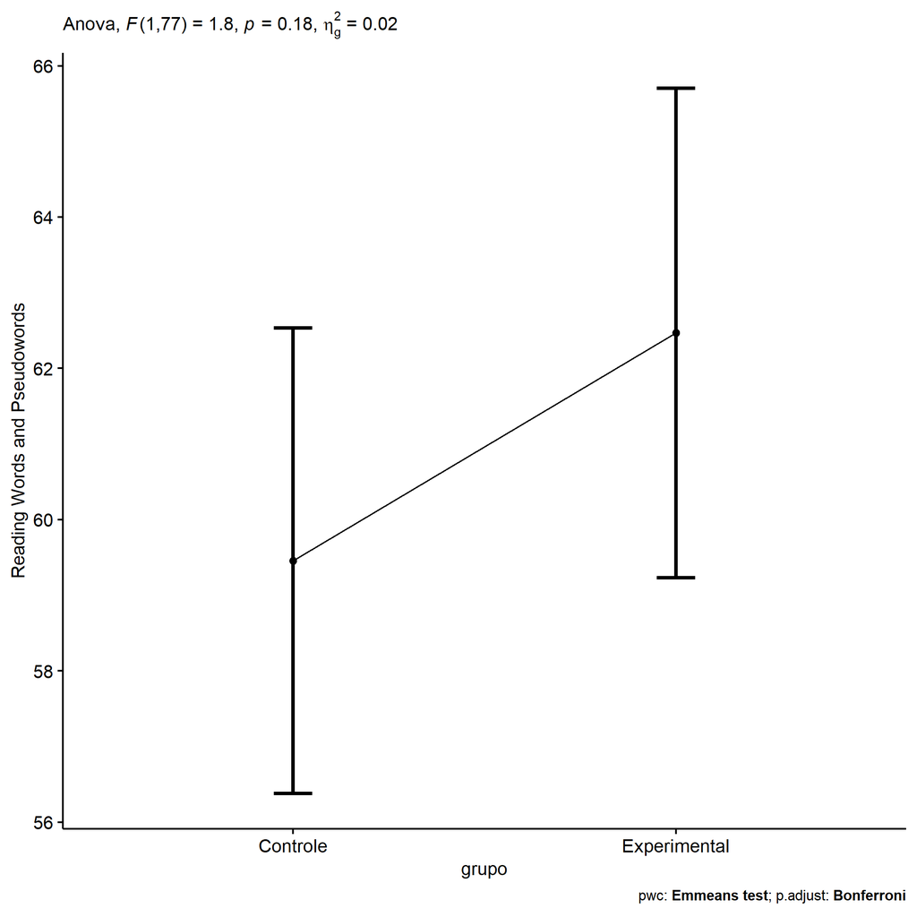

```r
if (!is.null(nrow(plots[["grupo"]]$data)))
  plots[["grupo"]] + ggplot2::ylab("Reading Words and Pseudowords") +
  if (ymin.ci < ymax.ci) ggplot2::ylim(ymin.ci, ymax.ci)
```

```r
plots <- oneWayAncovaBoxPlots(
  wdat, "score.CLPP.pos", "grupo", aov, pwc, covar = "score.CLPP.pre",
  theme = "classic", color = color[["grupo"]],
  subtitle = which(aov$Effect == "grupo"))
```

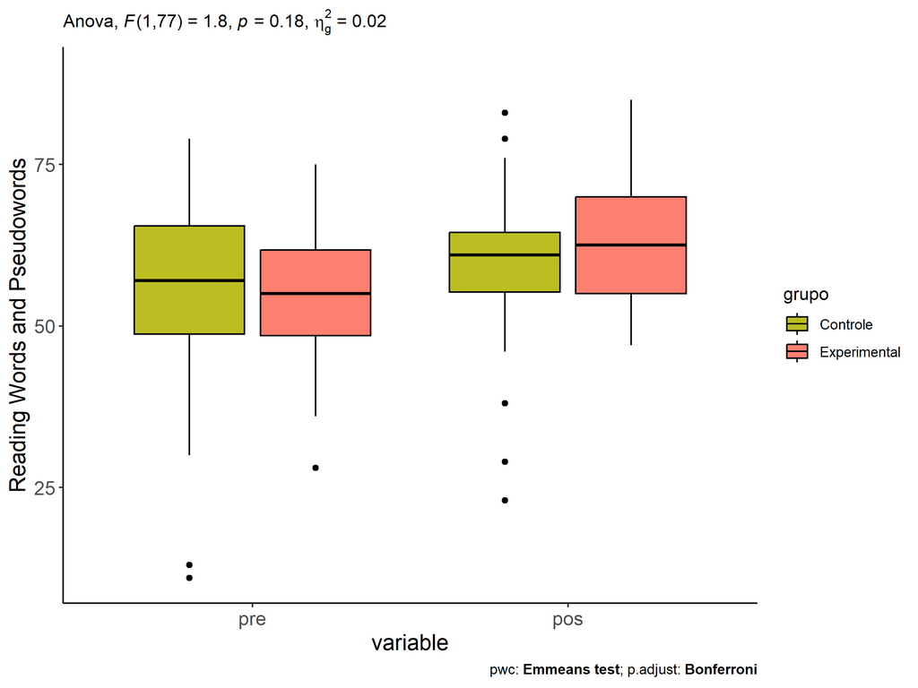

```r
if (length(unique(wdat[["grupo"]])) > 1)
  plots[["grupo"]] + ggplot2::ylab("Reading Words and Pseudowords") +
  ggplot2::scale_x_discrete(labels=c('pre', 'pos')) +
  if (ymin < ymax) ggplot2::ylim(ymin, ymax)
```

```r
if (length(unique(wdat.long[["grupo"]])) > 1)
  plots <- oneWayAncovaBoxPlots(
    wdat.long, "score.CLPP", "grupo", aov, pwc.long,
    pre.post = "time", theme = "classic", color = color$prepost)
```

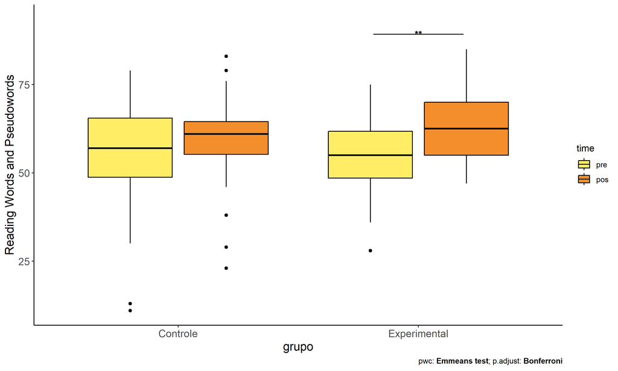

```r
if (length(unique(wdat.long[["grupo"]])) > 1)
  plots[["grupo"]] + ggplot2::ylab("Reading Words and Pseudowords") +
  if (ymin < ymax) ggplot2::ylim(ymin, ymax)
```

### Checking linearity assumption

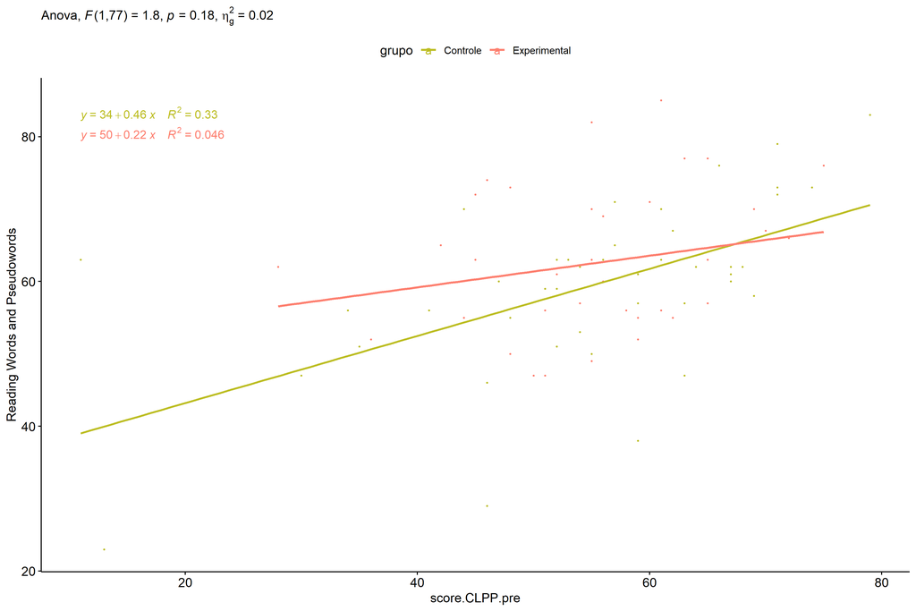

```r
ggscatter(wdat, x = "score.CLPP.pre", y = "score.CLPP.pos", size = 0.5,
          color = "grupo", add = "reg.line")+
  stat_regline_equation(
    aes(label =  paste(..eq.label.., ..rr.label.., sep = "~~~~"), color = grupo)
  ) +
  ggplot2::labs(subtitle = rstatix::get_test_label(aov, detailed = T, row = which(aov$Effect == "grupo"))) +
  ggplot2::scale_color_manual(values = color[["grupo"]]) +
  ggplot2::ylab("Reading Words and Pseudowords")  +
  if (ymin < ymax) ggplot2::ylim(ymin, ymax)
```

### Checking normality and homogeneity

```r
res <- augment(lm(score.CLPP.pos ~ score.CLPP.pre + grupo, data = wdat))
```

```r
shapiro_test(res$.resid)
```

```
## # A tibble: 1 × 3
##   variable   statistic p.value
##   <chr>          <dbl>   <dbl>
## 1 res$.resid     0.991   0.877
```

```r
levene_test(res, .resid ~ grupo)
```

```
## # A tibble: 1 × 4
##     df1   df2 statistic     p
##   <int> <int>     <dbl> <dbl>
## 1     1    78     0.772 0.382
```

# ANCOVA and Pairwise for two factors **grupo:genero**

## Without remove non-normal data

```r
pdat = remove_group_data(dat[!is.na(dat[["grupo"]]) & !is.na(dat[["genero"]]),],
                         "score.CLPP.pos", c("grupo","genero"))
pdat = pdat[pdat[["genero"]] %in% do.call(
  intersect, lapply(unique(pdat[["grupo"]]), FUN = function(x) {
    unique(pdat[["genero"]][which(pdat[["grupo"]] == x)])
  })),]
pdat[["grupo"]] = factor(pdat[["grupo"]], level[["grupo"]])
pdat[["genero"]] = factor(
  pdat[["genero"]],
  level[["genero"]][level[["genero"]] %in% unique(pdat[["genero"]])])

pdat.long <- rbind(pdat[,c("id","grupo","genero")], pdat[,c("id","grupo","genero")])
pdat.long[["time"]] <- c(rep("pre", nrow(pdat)), rep("pos", nrow(pdat)))
pdat.long[["time"]] <- factor(pdat.long[["time"]], c("pre","pos"))
pdat.long[["score.CLPP"]] <- c(pdat[["score.CLPP.pre"]], pdat[["score.CLPP.pos"]])

if (length(unique(pdat[["genero"]])) >= 2) {
  aov = anova_test(pdat, score.CLPP.pos ~ score.CLPP.pre + grupo*genero)
  laov[["grupo:genero"]] <- get_anova_table(aov)
}
```

```r
if (length(unique(pdat[["genero"]])) >= 2) {
  pwcs <- list()
  pwcs[["genero"]] <- emmeans_test(
    group_by(pdat, grupo), score.CLPP.pos ~ genero,
    covariate = score.CLPP.pre, p.adjust.method = "bonferroni")
  pwcs[["grupo"]] <- emmeans_test(
    group_by(pdat, genero), score.CLPP.pos ~ grupo,
    covariate = score.CLPP.pre, p.adjust.method = "bonferroni")

  pwc <- plyr::rbind.fill(pwcs[["grupo"]], pwcs[["genero"]])
  pwc <- pwc[,c("grupo","genero", colnames(pwc)[!colnames(pwc) %in% c("grupo","genero")])]
}
```

```r
if (length(unique(pdat[["genero"]])) >= 2) {
  pwc.long <- emmeans_test(dplyr::group_by_at(pdat.long, c("grupo","genero")),
                           score.CLPP ~ time,
                           p.adjust.method = "bonferroni")
  lpwc[["grupo:genero"]] <- plyr::rbind.fill(pwc, pwc.long)
}
```

```r
if (length(unique(pdat[["genero"]])) >= 2) {
  ds <- get.descriptives(pdat, "score.CLPP.pos", c("grupo","genero"), covar = "score.CLPP.pre")
  ds <- merge(ds[ds$variable != "score.CLPP.pre",],
              ds[ds$variable == "score.CLPP.pre", !colnames(ds) %in% c("variable")],
              by = c("grupo","genero"), all.x = T, suffixes = c("", ".score.CLPP.pre"))
  ds <- merge(get_emmeans(pwcs[["grupo"]]), ds,
              by = c("grupo","genero"), suffixes = c(".emms", ""))
  ds <- ds[,c("grupo","genero","n","mean.score.CLPP.pre","se.score.CLPP.pre","mean","se",
              "emmean","se.emms","conf.low","conf.high")]

  colnames(ds) <- c("grupo","genero", "N", paste0(c("M","SE")," (pre)"),
                    paste0(c("M","SE"), " (unadj)"),
                    paste0(c("M", "SE"), " (adj)"), "conf.low", "conf.high")

  lemms[["grupo:genero"]] <- ds
}
```

## Computing ANCOVA and PairWise After removing non-normal data (OK)

```r
if (length(unique(pdat[["genero"]])) >= 2) {
  wdat = pdat

  res = residuals(lm(score.CLPP.pos ~ score.CLPP.pre + grupo*genero, data = wdat))
  non.normal = getNonNormal(res, wdat$id, plimit = 0.05)

  wdat = wdat[!wdat$id %in% non.normal,]

  wdat.long <- rbind(wdat[,c("id","grupo","genero")], wdat[,c("id","grupo","genero")])
  wdat.long[["time"]] <- c(rep("pre", nrow(wdat)), rep("pos", nrow(wdat)))
  wdat.long[["time"]] <- factor(wdat.long[["time"]], c("pre","pos"))
  wdat.long[["score.CLPP"]] <- c(wdat[["score.CLPP.pre"]], wdat[["score.CLPP.pos"]])


  ldat[["grupo:genero"]] = wdat

  (non.normal)
}
```

```r
if (length(unique(pdat[["genero"]])) >= 2) {
  aov = anova_test(wdat, score.CLPP.pos ~ score.CLPP.pre + grupo*genero)
  laov[["grupo:genero"]] <- merge(get_anova_table(aov), laov[["grupo:genero"]],
                                         by="Effect", suffixes = c("","'"))
  df = get_anova_table(aov)
}
```

| Effect | DFn | DFd | F | p | p<.05 | ges |
| --- | --- | --- | --- | --- | --- | --- |
| score.CLPP.pre | 1 | 75 | 16.517 | 0.000 | * | 0.180 |
| grupo | 1 | 75 | 1.879 | 0.174 |  | 0.024 |
| genero | 1 | 75 | 0.328 | 0.568 |  | 0.004 |
| grupo:genero | 1 | 75 | 0.175 | 0.677 |  | 0.002 |

```r
if (length(unique(pdat[["genero"]])) >= 2) {
  pwcs <- list()
  pwcs[["genero"]] <- emmeans_test(
    group_by(wdat, grupo), score.CLPP.pos ~ genero,
    covariate = score.CLPP.pre, p.adjust.method = "bonferroni")
  pwcs[["grupo"]] <- emmeans_test(
    group_by(wdat, genero), score.CLPP.pos ~ grupo,
    covariate = score.CLPP.pre, p.adjust.method = "bonferroni")

  pwc <- plyr::rbind.fill(pwcs[["grupo"]], pwcs[["genero"]])
  pwc <- pwc[,c("grupo","genero", colnames(pwc)[!colnames(pwc) %in% c("grupo","genero")])]
}
```

| grupo | genero | term | .y. | group1 | group2 | df | statistic | p | p.adj | p.adj.signif |
| --- | --- | --- | --- | --- | --- | --- | --- | --- | --- | --- |
|  | F | score.CLPP.pre*grupo | score.CLPP.pos | Controle | Experimental | 75 | -1.254 | 0.214 | 0.214 | ns |
|  | M | score.CLPP.pre*grupo | score.CLPP.pos | Controle | Experimental | 75 | -0.694 | 0.490 | 0.490 | ns |
| Controle |  | score.CLPP.pre*genero | score.CLPP.pos | F | M | 75 | 0.141 | 0.889 | 0.889 | ns |
| Experimental |  | score.CLPP.pre*genero | score.CLPP.pos | F | M | 75 | 0.699 | 0.487 | 0.487 | ns |

```r
if (length(unique(pdat[["genero"]])) >= 2) {
  pwc.long <- emmeans_test(dplyr::group_by_at(wdat.long, c("grupo","genero")),
                           score.CLPP ~ time,
                           p.adjust.method = "bonferroni")
  lpwc[["grupo:genero"]] <- merge(plyr::rbind.fill(pwc, pwc.long),
                                         lpwc[["grupo:genero"]],
                                         by=c("grupo","genero","term",".y.","group1","group2"),
                                         suffixes = c("","'"))
}
```

| grupo | genero | term | .y. | group1 | group2 | df | statistic | p | p.adj | p.adj.signif |
| --- | --- | --- | --- | --- | --- | --- | --- | --- | --- | --- |
| Controle | F | time | score.CLPP | pre | pos | 152 | -0.931 | 0.353 | 0.353 | ns |
| Controle | M | time | score.CLPP | pre | pos | 152 | -1.525 | 0.129 | 0.129 | ns |
| Experimental | F | time | score.CLPP | pre | pos | 152 | -1.552 | 0.123 | 0.123 | ns |
| Experimental | M | time | score.CLPP | pre | pos | 152 | -2.258 | 0.025 | 0.025 | * |

```r
if (length(unique(pdat[["genero"]])) >= 2) {
  ds <- get.descriptives(wdat, "score.CLPP.pos", c("grupo","genero"), covar = "score.CLPP.pre")
  ds <- merge(ds[ds$variable != "score.CLPP.pre",],
              ds[ds$variable == "score.CLPP.pre", !colnames(ds) %in% c("variable")],
              by = c("grupo","genero"), all.x = T, suffixes = c("", ".score.CLPP.pre"))
  ds <- merge(get_emmeans(pwcs[["grupo"]]), ds,
              by = c("grupo","genero"), suffixes = c(".emms", ""))
  ds <- ds[,c("grupo","genero","n","mean.score.CLPP.pre","se.score.CLPP.pre",
              "mean","se","emmean","se.emms","conf.low","conf.high")]

  colnames(ds) <- c("grupo","genero", "N", paste0(c("M","SE")," (pre)"),
                    paste0(c("M","SE"), " (unadj)"),
                    paste0(c("M", "SE"), " (adj)"), "conf.low", "conf.high")

  lemms[["grupo:genero"]] <- merge(ds, lemms[["grupo:genero"]],
                                          by=c("grupo","genero"), suffixes = c("","'"))
}
```

| grupo | genero | N | M (pre) | SE (pre) | M (unadj) | SE (unadj) | M (adj) | SE (adj) | conf.low | conf.high |
| --- | --- | --- | --- | --- | --- | --- | --- | --- | --- | --- |
| Controle | F | 22 | 57.136 | 3.131 | 60.455 | 2.703 | 59.668 | 2.165 | 55.354 | 63.981 |
| Controle | M | 20 | 52.600 | 3.274 | 58.300 | 2.507 | 59.224 | 2.273 | 54.696 | 63.752 |
| Experimental | F | 17 | 58.941 | 2.222 | 65.235 | 2.455 | 63.768 | 2.480 | 58.828 | 68.707 |
| Experimental | M | 21 | 52.048 | 2.145 | 60.286 | 2.160 | 61.418 | 2.225 | 56.986 | 65.850 |

### Plots for ancova

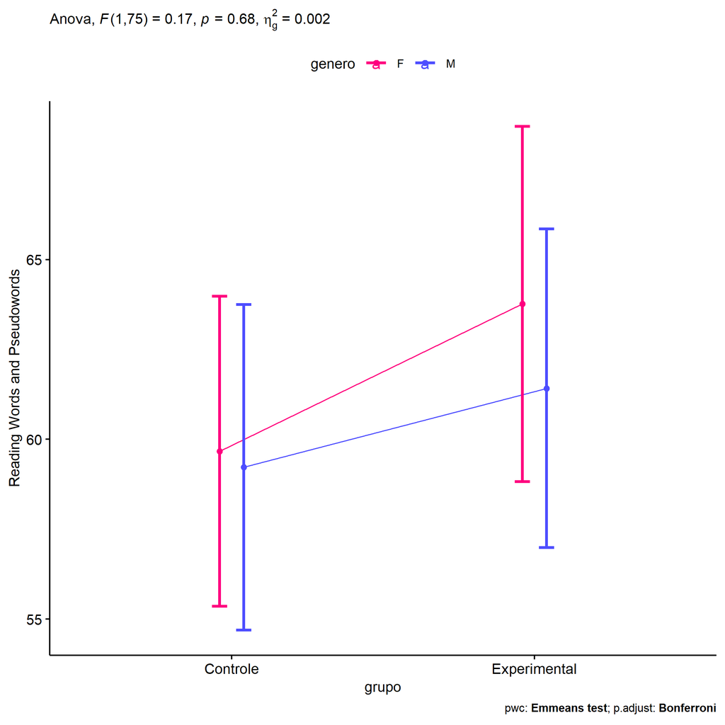

```r
if (length(unique(pdat[["genero"]])) >= 2) {
  ggPlotAoC2(pwcs, "grupo", "genero", aov, ylab = "Reading Words and Pseudowords",
             subtitle = which(aov$Effect == "grupo:genero"), addParam = "errorbar") +
    ggplot2::scale_color_manual(values = color[["genero"]]) +
    ggplot2::ylab("Reading Words and Pseudowords") +
    if (ymin.ci < ymax.ci) ggplot2::ylim(ymin.ci, ymax.ci)
}
```

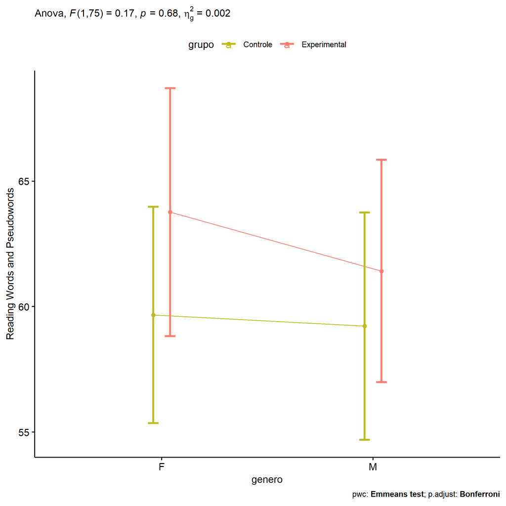

```r
if (length(unique(pdat[["genero"]])) >= 2) {
  ggPlotAoC2(pwcs, "genero", "grupo", aov, ylab = "Reading Words and Pseudowords",
               subtitle = which(aov$Effect == "grupo:genero"), addParam = "errorbar") +
    ggplot2::scale_color_manual(values = color[["grupo"]]) +
    ggplot2::ylab("Reading Words and Pseudowords") +
    if (ymin.ci < ymax.ci) ggplot2::ylim(ymin.ci, ymax.ci)
}
```

```r
if (length(unique(pdat[["genero"]])) >= 2) {
  plots <- twoWayAncovaBoxPlots(
    wdat, "score.CLPP.pos", c("grupo","genero"), aov, pwcs, covar = "score.CLPP.pre",
    theme = "classic", color = color[["grupo:genero"]],
    subtitle = which(aov$Effect == "grupo:genero"))
}
```

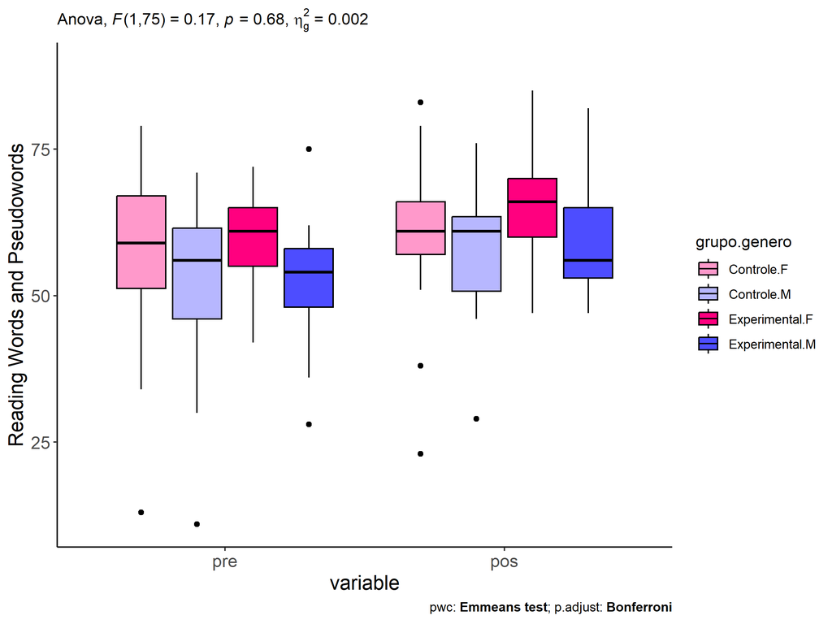

```r
if (length(unique(pdat[["genero"]])) >= 2) {
  plots[["grupo:genero"]] + ggplot2::ylab("Reading Words and Pseudowords") +
  ggplot2::scale_x_discrete(labels=c('pre', 'pos')) +
  if (ymin < ymax) ggplot2::ylim(ymin, ymax)
}
```

```r
if (length(unique(pdat[["genero"]])) >= 2) {
  plots <- twoWayAncovaBoxPlots(
    wdat.long, "score.CLPP", c("grupo","genero"), aov, pwc.long,
    pre.post = "time",
    theme = "classic", color = color$prepost)
}
```

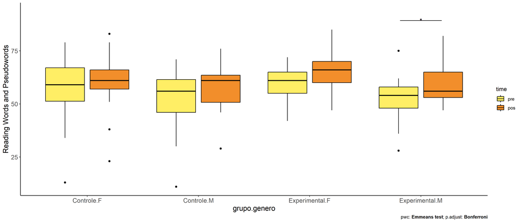

```r
if (length(unique(pdat[["genero"]])) >= 2)
  plots[["grupo:genero"]] + ggplot2::ylab("Reading Words and Pseudowords") +
    if (ymin < ymax) ggplot2::ylim(ymin, ymax)
```

### Checking linearity assumption

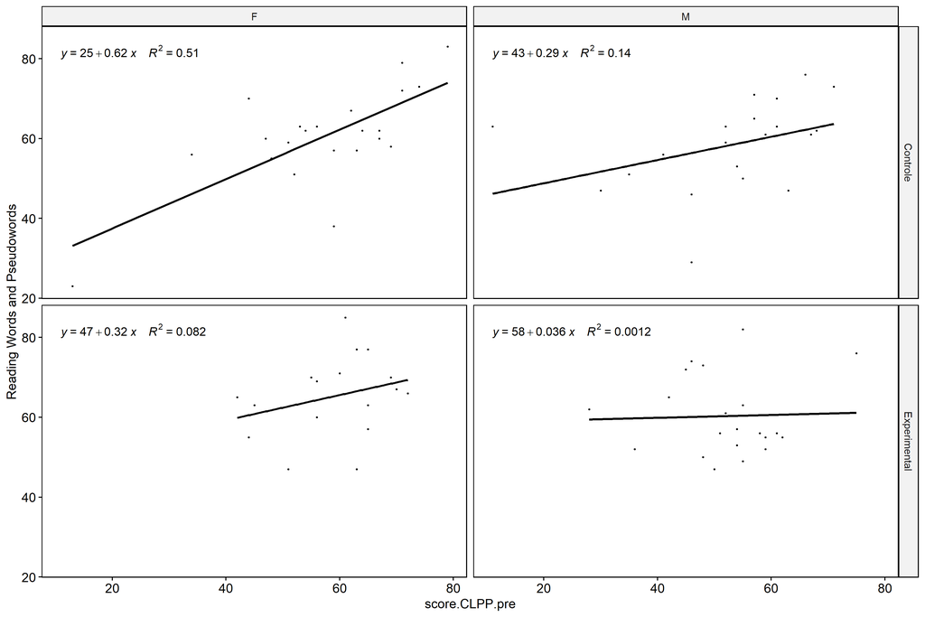

```r
if (length(unique(pdat[["genero"]])) >= 2) {
  ggscatter(wdat, x = "score.CLPP.pre", y = "score.CLPP.pos", size = 0.5,
            facet.by = c("grupo","genero"), add = "reg.line")+
    stat_regline_equation(
      aes(label =  paste(..eq.label.., ..rr.label.., sep = "~~~~"))
    ) + ggplot2::ylab("Reading Words and Pseudowords") +
    if (ymin < ymax) ggplot2::ylim(ymin, ymax)
}
```

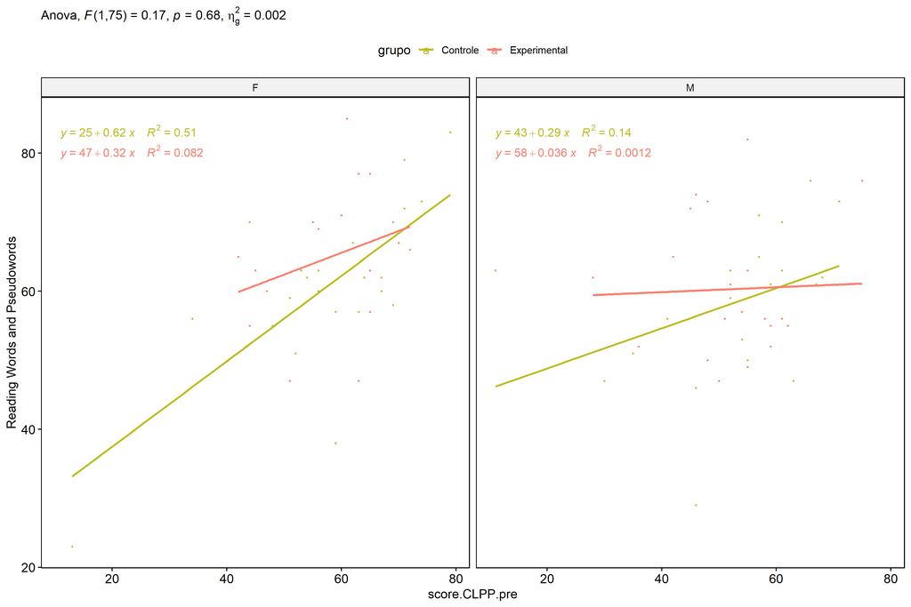

```r
if (length(unique(pdat[["genero"]])) >= 2) {
  ggscatter(wdat, x = "score.CLPP.pre", y = "score.CLPP.pos", size = 0.5,
            color = "grupo", facet.by = "genero", add = "reg.line")+
    stat_regline_equation(
      aes(label =  paste(..eq.label.., ..rr.label.., sep = "~~~~"), color = grupo)
    ) +
    ggplot2::labs(subtitle = rstatix::get_test_label(aov, detailed = T, row = which(aov$Effect == "grupo:genero"))) +
    ggplot2::scale_color_manual(values = color[["grupo"]]) +
    ggplot2::ylab("Reading Words and Pseudowords") +
    if (ymin < ymax) ggplot2::ylim(ymin, ymax)
}
```

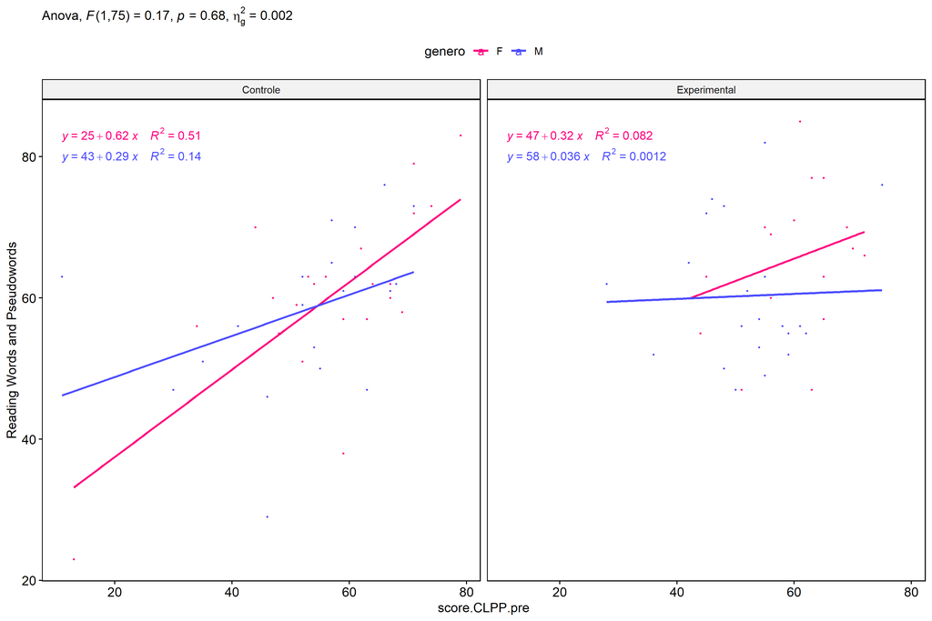

```r
if (length(unique(pdat[["genero"]])) >= 2) {
  ggscatter(wdat, x = "score.CLPP.pre", y = "score.CLPP.pos", size = 0.5,
            color = "genero", facet.by = "grupo", add = "reg.line")+
    stat_regline_equation(
      aes(label =  paste(..eq.label.., ..rr.label.., sep = "~~~~"), color = genero)
    ) +
    ggplot2::labs(subtitle = rstatix::get_test_label(aov, detailed = T, row = which(aov$Effect == "grupo:genero"))) +
    ggplot2::scale_color_manual(values = color[["genero"]]) +
    ggplot2::ylab("Reading Words and Pseudowords") +
    if (ymin < ymax) ggplot2::ylim(ymin, ymax)
}
```

### Checking normality and homogeneity

```r
if (length(unique(pdat[["genero"]])) >= 2)
  res <- augment(lm(score.CLPP.pos ~ score.CLPP.pre + grupo*genero, data = wdat))
```

```r
if (length(unique(pdat[["genero"]])) >= 2)
  shapiro_test(res$.resid)
```

```
## # A tibble: 1 × 3
##   variable   statistic p.value
##   <chr>          <dbl>   <dbl>
## 1 res$.resid     0.990   0.768
```

```r
if (length(unique(pdat[["genero"]])) >= 2)
  levene_test(res, .resid ~ grupo*genero)
```

```
## # A tibble: 1 × 4
##     df1   df2 statistic     p
##   <int> <int>     <dbl> <dbl>
## 1     3    76     0.204 0.893
```

# ANCOVA and Pairwise for two factors **grupo:zona.participante**

## Without remove non-normal data

```r
pdat = remove_group_data(dat[!is.na(dat[["grupo"]]) & !is.na(dat[["zona.participante"]]),],
                         "score.CLPP.pos", c("grupo","zona.participante"))
pdat = pdat[pdat[["zona.participante"]] %in% do.call(
  intersect, lapply(unique(pdat[["grupo"]]), FUN = function(x) {
    unique(pdat[["zona.participante"]][which(pdat[["grupo"]] == x)])
  })),]
pdat[["grupo"]] = factor(pdat[["grupo"]], level[["grupo"]])
pdat[["zona.participante"]] = factor(
  pdat[["zona.participante"]],
  level[["zona.participante"]][level[["zona.participante"]] %in% unique(pdat[["zona.participante"]])])

pdat.long <- rbind(pdat[,c("id","grupo","zona.participante")], pdat[,c("id","grupo","zona.participante")])
pdat.long[["time"]] <- c(rep("pre", nrow(pdat)), rep("pos", nrow(pdat)))
pdat.long[["time"]] <- factor(pdat.long[["time"]], c("pre","pos"))
pdat.long[["score.CLPP"]] <- c(pdat[["score.CLPP.pre"]], pdat[["score.CLPP.pos"]])

if (length(unique(pdat[["zona.participante"]])) >= 2) {
  aov = anova_test(pdat, score.CLPP.pos ~ score.CLPP.pre + grupo*zona.participante)
  laov[["grupo:zona.participante"]] <- get_anova_table(aov)
}
```

```r
if (length(unique(pdat[["zona.participante"]])) >= 2) {
  pwcs <- list()
  pwcs[["zona.participante"]] <- emmeans_test(
    group_by(pdat, grupo), score.CLPP.pos ~ zona.participante,
    covariate = score.CLPP.pre, p.adjust.method = "bonferroni")
  pwcs[["grupo"]] <- emmeans_test(
    group_by(pdat, zona.participante), score.CLPP.pos ~ grupo,
    covariate = score.CLPP.pre, p.adjust.method = "bonferroni")

  pwc <- plyr::rbind.fill(pwcs[["grupo"]], pwcs[["zona.participante"]])
  pwc <- pwc[,c("grupo","zona.participante", colnames(pwc)[!colnames(pwc) %in% c("grupo","zona.participante")])]
}
```

```r
if (length(unique(pdat[["zona.participante"]])) >= 2) {
  pwc.long <- emmeans_test(dplyr::group_by_at(pdat.long, c("grupo","zona.participante")),
                           score.CLPP ~ time,
                           p.adjust.method = "bonferroni")
  lpwc[["grupo:zona.participante"]] <- plyr::rbind.fill(pwc, pwc.long)
}
```

```r
if (length(unique(pdat[["zona.participante"]])) >= 2) {
  ds <- get.descriptives(pdat, "score.CLPP.pos", c("grupo","zona.participante"), covar = "score.CLPP.pre")
  ds <- merge(ds[ds$variable != "score.CLPP.pre",],
              ds[ds$variable == "score.CLPP.pre", !colnames(ds) %in% c("variable")],
              by = c("grupo","zona.participante"), all.x = T, suffixes = c("", ".score.CLPP.pre"))
  ds <- merge(get_emmeans(pwcs[["grupo"]]), ds,
              by = c("grupo","zona.participante"), suffixes = c(".emms", ""))
  ds <- ds[,c("grupo","zona.participante","n","mean.score.CLPP.pre","se.score.CLPP.pre","mean","se",
              "emmean","se.emms","conf.low","conf.high")]

  colnames(ds) <- c("grupo","zona.participante", "N", paste0(c("M","SE")," (pre)"),
                    paste0(c("M","SE"), " (unadj)"),
                    paste0(c("M", "SE"), " (adj)"), "conf.low", "conf.high")

  lemms[["grupo:zona.participante"]] <- ds
}
```

## Computing ANCOVA and PairWise After removing non-normal data (OK)

```r
if (length(unique(pdat[["zona.participante"]])) >= 2) {
  wdat = pdat

  res = residuals(lm(score.CLPP.pos ~ score.CLPP.pre + grupo*zona.participante, data = wdat))
  non.normal = getNonNormal(res, wdat$id, plimit = 0.05)

  wdat = wdat[!wdat$id %in% non.normal,]

  wdat.long <- rbind(wdat[,c("id","grupo","zona.participante")], wdat[,c("id","grupo","zona.participante")])
  wdat.long[["time"]] <- c(rep("pre", nrow(wdat)), rep("pos", nrow(wdat)))
  wdat.long[["time"]] <- factor(wdat.long[["time"]], c("pre","pos"))
  wdat.long[["score.CLPP"]] <- c(wdat[["score.CLPP.pre"]], wdat[["score.CLPP.pos"]])


  ldat[["grupo:zona.participante"]] = wdat

  (non.normal)
}
```

```r
if (length(unique(pdat[["zona.participante"]])) >= 2) {
  aov = anova_test(wdat, score.CLPP.pos ~ score.CLPP.pre + grupo*zona.participante)
  laov[["grupo:zona.participante"]] <- merge(get_anova_table(aov), laov[["grupo:zona.participante"]],
                                         by="Effect", suffixes = c("","'"))
  df = get_anova_table(aov)
}
```

| Effect | DFn | DFd | F | p | p<.05 | ges |
| --- | --- | --- | --- | --- | --- | --- |
| score.CLPP.pre | 1 | 55 | 22.386 | 0.000 | * | 0.289 |
| grupo | 1 | 55 | 2.976 | 0.090 |  | 0.051 |
| zona.participante | 1 | 55 | 0.749 | 0.391 |  | 0.013 |
| grupo:zona.participante | 1 | 55 | 0.000 | 0.993 |  | 0.000 |

```r
if (length(unique(pdat[["zona.participante"]])) >= 2) {
  pwcs <- list()
  pwcs[["zona.participante"]] <- emmeans_test(
    group_by(wdat, grupo), score.CLPP.pos ~ zona.participante,
    covariate = score.CLPP.pre, p.adjust.method = "bonferroni")
  pwcs[["grupo"]] <- emmeans_test(
    group_by(wdat, zona.participante), score.CLPP.pos ~ grupo,
    covariate = score.CLPP.pre, p.adjust.method = "bonferroni")

  pwc <- plyr::rbind.fill(pwcs[["grupo"]], pwcs[["zona.participante"]])
  pwc <- pwc[,c("grupo","zona.participante", colnames(pwc)[!colnames(pwc) %in% c("grupo","zona.participante")])]
}
```

| grupo | zona.participante | term | .y. | group1 | group2 | df | statistic | p | p.adj | p.adj.signif |
| --- | --- | --- | --- | --- | --- | --- | --- | --- | --- | --- |
|  | Rural | score.CLPP.pre*grupo | score.CLPP.pos | Controle | Experimental | 55 | -1.113 | 0.271 | 0.271 | ns |
|  | Urbana | score.CLPP.pre*grupo | score.CLPP.pos | Controle | Experimental | 55 | -1.307 | 0.197 | 0.197 | ns |
| Controle |  | score.CLPP.pre*zona.participante | score.CLPP.pos | Rural | Urbana | 55 | -0.612 | 0.543 | 0.543 | ns |
| Experimental |  | score.CLPP.pre*zona.participante | score.CLPP.pos | Rural | Urbana | 55 | -0.608 | 0.546 | 0.546 | ns |

```r
if (length(unique(pdat[["zona.participante"]])) >= 2) {
  pwc.long <- emmeans_test(dplyr::group_by_at(wdat.long, c("grupo","zona.participante")),
                           score.CLPP ~ time,
                           p.adjust.method = "bonferroni")
  lpwc[["grupo:zona.participante"]] <- merge(plyr::rbind.fill(pwc, pwc.long),
                                         lpwc[["grupo:zona.participante"]],
                                         by=c("grupo","zona.participante","term",".y.","group1","group2"),
                                         suffixes = c("","'"))
}
```

| grupo | zona.participante | term | .y. | group1 | group2 | df | statistic | p | p.adj | p.adj.signif |
| --- | --- | --- | --- | --- | --- | --- | --- | --- | --- | --- |
| Controle | Rural | time | score.CLPP | pre | pos | 112 | -0.552 | 0.582 | 0.582 | ns |
| Controle | Urbana | time | score.CLPP | pre | pos | 112 | -1.212 | 0.228 | 0.228 | ns |
| Experimental | Rural | time | score.CLPP | pre | pos | 112 | -1.295 | 0.198 | 0.198 | ns |
| Experimental | Urbana | time | score.CLPP | pre | pos | 112 | -2.416 | 0.017 | 0.017 | * |

```r
if (length(unique(pdat[["zona.participante"]])) >= 2) {
  ds <- get.descriptives(wdat, "score.CLPP.pos", c("grupo","zona.participante"), covar = "score.CLPP.pre")
  ds <- merge(ds[ds$variable != "score.CLPP.pre",],
              ds[ds$variable == "score.CLPP.pre", !colnames(ds) %in% c("variable")],
              by = c("grupo","zona.participante"), all.x = T, suffixes = c("", ".score.CLPP.pre"))
  ds <- merge(get_emmeans(pwcs[["grupo"]]), ds,
              by = c("grupo","zona.participante"), suffixes = c(".emms", ""))
  ds <- ds[,c("grupo","zona.participante","n","mean.score.CLPP.pre","se.score.CLPP.pre",
              "mean","se","emmean","se.emms","conf.low","conf.high")]

  colnames(ds) <- c("grupo","zona.participante", "N", paste0(c("M","SE")," (pre)"),
                    paste0(c("M","SE"), " (unadj)"),
                    paste0(c("M", "SE"), " (adj)"), "conf.low", "conf.high")

  lemms[["grupo:zona.participante"]] <- merge(ds, lemms[["grupo:zona.participante"]],
                                          by=c("grupo","zona.participante"), suffixes = c("","'"))
}
```

| grupo | zona.participante | N | M (pre) | SE (pre) | M (unadj) | SE (unadj) | M (adj) | SE (adj) | conf.low | conf.high |
| --- | --- | --- | --- | --- | --- | --- | --- | --- | --- | --- |
| Controle | Rural | 11 | 55.818 | 3.193 | 58.636 | 1.965 | 58.874 | 2.989 | 52.884 | 64.863 |
| Controle | Urbana | 21 | 57.048 | 3.334 | 61.524 | 3.039 | 61.134 | 2.164 | 56.796 | 65.471 |
| Experimental | Rural | 14 | 58.714 | 3.198 | 64.571 | 3.429 | 63.331 | 2.662 | 57.997 | 68.665 |
| Experimental | Urbana | 14 | 53.071 | 2.087 | 64.000 | 2.522 | 65.639 | 2.671 | 60.285 | 70.992 |

### Plots for ancova

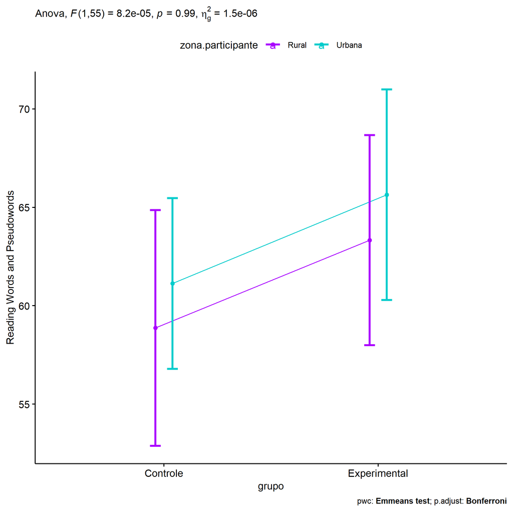

```r
if (length(unique(pdat[["zona.participante"]])) >= 2) {
  ggPlotAoC2(pwcs, "grupo", "zona.participante", aov, ylab = "Reading Words and Pseudowords",
             subtitle = which(aov$Effect == "grupo:zona.participante"), addParam = "errorbar") +
    ggplot2::scale_color_manual(values = color[["zona.participante"]]) +
    ggplot2::ylab("Reading Words and Pseudowords") +
    if (ymin.ci < ymax.ci) ggplot2::ylim(ymin.ci, ymax.ci)
}
```

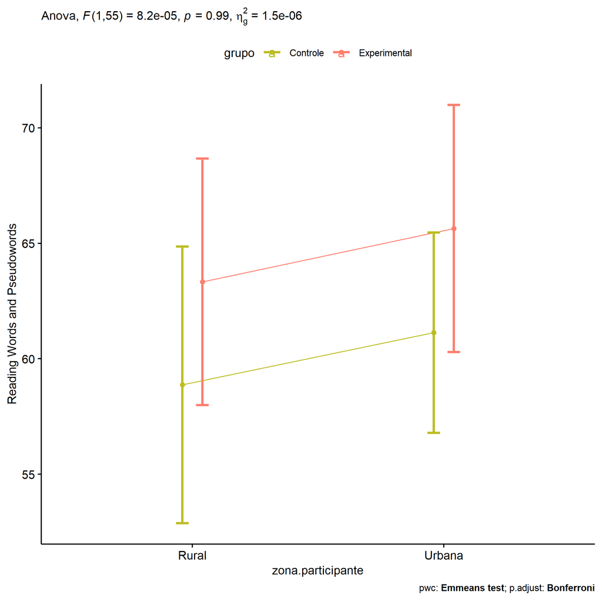

```r
if (length(unique(pdat[["zona.participante"]])) >= 2) {
  ggPlotAoC2(pwcs, "zona.participante", "grupo", aov, ylab = "Reading Words and Pseudowords",
               subtitle = which(aov$Effect == "grupo:zona.participante"), addParam = "errorbar") +
    ggplot2::scale_color_manual(values = color[["grupo"]]) +
    ggplot2::ylab("Reading Words and Pseudowords") +
    if (ymin.ci < ymax.ci) ggplot2::ylim(ymin.ci, ymax.ci)
}
```

```r
if (length(unique(pdat[["zona.participante"]])) >= 2) {
  plots <- twoWayAncovaBoxPlots(
    wdat, "score.CLPP.pos", c("grupo","zona.participante"), aov, pwcs, covar = "score.CLPP.pre",
    theme = "classic", color = color[["grupo:zona.participante"]],
    subtitle = which(aov$Effect == "grupo:zona.participante"))
}
```

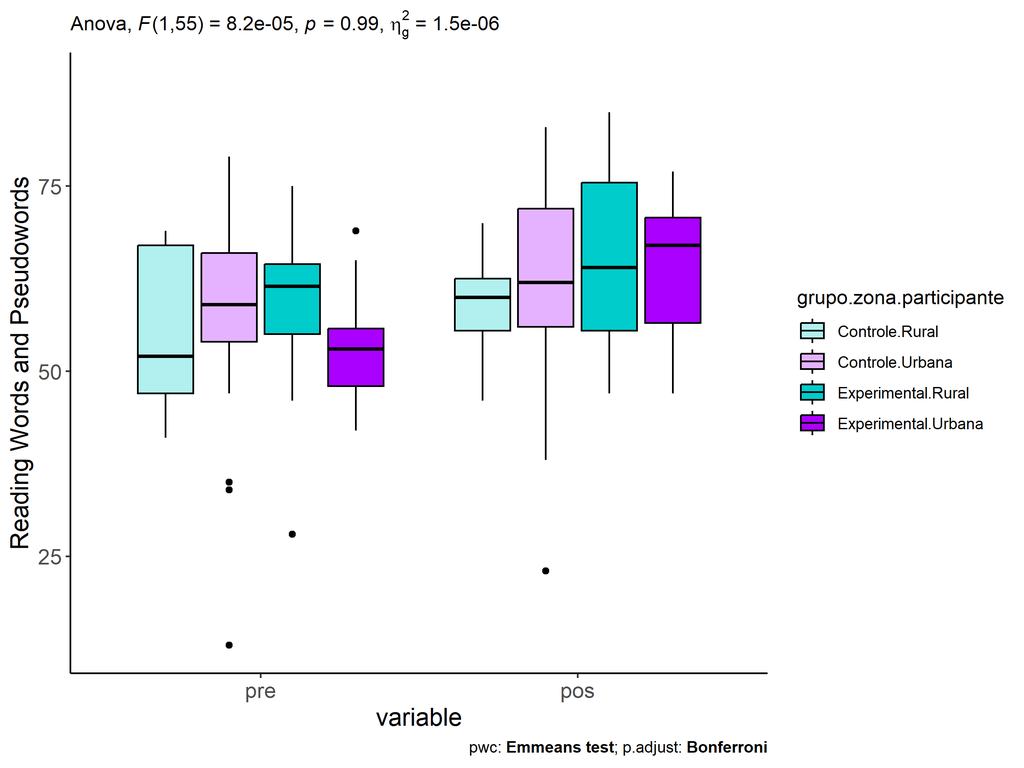

```r
if (length(unique(pdat[["zona.participante"]])) >= 2) {
  plots[["grupo:zona.participante"]] + ggplot2::ylab("Reading Words and Pseudowords") +
  ggplot2::scale_x_discrete(labels=c('pre', 'pos')) +
  if (ymin < ymax) ggplot2::ylim(ymin, ymax)
}
```

```r
if (length(unique(pdat[["zona.participante"]])) >= 2) {
  plots <- twoWayAncovaBoxPlots(
    wdat.long, "score.CLPP", c("grupo","zona.participante"), aov, pwc.long,
    pre.post = "time",
    theme = "classic", color = color$prepost)
}
```

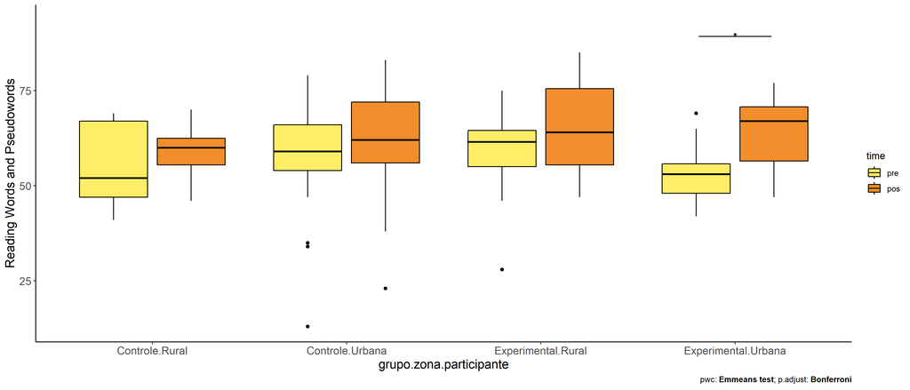

```r
if (length(unique(pdat[["zona.participante"]])) >= 2)
  plots[["grupo:zona.participante"]] + ggplot2::ylab("Reading Words and Pseudowords") +
    if (ymin < ymax) ggplot2::ylim(ymin, ymax)
```

### Checking linearity assumption

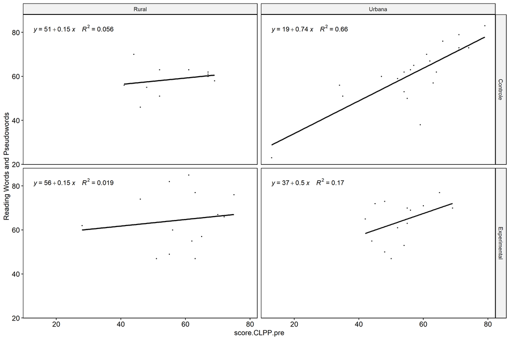

```r
if (length(unique(pdat[["zona.participante"]])) >= 2) {
  ggscatter(wdat, x = "score.CLPP.pre", y = "score.CLPP.pos", size = 0.5,
            facet.by = c("grupo","zona.participante"), add = "reg.line")+
    stat_regline_equation(
      aes(label =  paste(..eq.label.., ..rr.label.., sep = "~~~~"))
    ) + ggplot2::ylab("Reading Words and Pseudowords") +
    if (ymin < ymax) ggplot2::ylim(ymin, ymax)
}
```

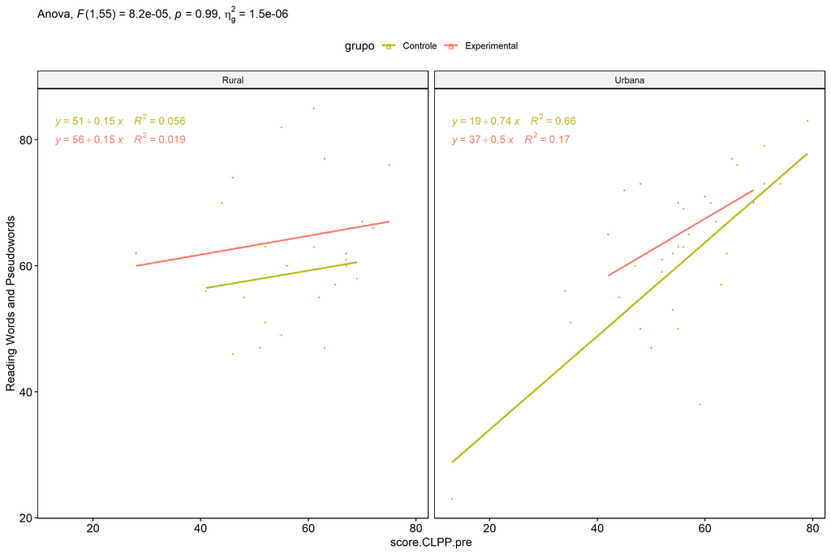

```r
if (length(unique(pdat[["zona.participante"]])) >= 2) {
  ggscatter(wdat, x = "score.CLPP.pre", y = "score.CLPP.pos", size = 0.5,
            color = "grupo", facet.by = "zona.participante", add = "reg.line")+
    stat_regline_equation(
      aes(label =  paste(..eq.label.., ..rr.label.., sep = "~~~~"), color = grupo)
    ) +
    ggplot2::labs(subtitle = rstatix::get_test_label(aov, detailed = T, row = which(aov$Effect == "grupo:zona.participante"))) +
    ggplot2::scale_color_manual(values = color[["grupo"]]) +
    ggplot2::ylab("Reading Words and Pseudowords") +
    if (ymin < ymax) ggplot2::ylim(ymin, ymax)
}
```

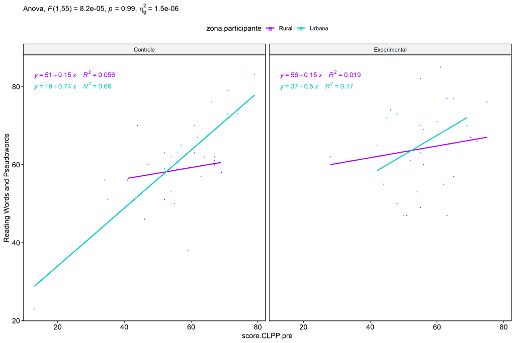

```r
if (length(unique(pdat[["zona.participante"]])) >= 2) {
  ggscatter(wdat, x = "score.CLPP.pre", y = "score.CLPP.pos", size = 0.5,
            color = "zona.participante", facet.by = "grupo", add = "reg.line")+
    stat_regline_equation(
      aes(label =  paste(..eq.label.., ..rr.label.., sep = "~~~~"), color = zona.participante)
    ) +
    ggplot2::labs(subtitle = rstatix::get_test_label(aov, detailed = T, row = which(aov$Effect == "grupo:zona.participante"))) +
    ggplot2::scale_color_manual(values = color[["zona.participante"]]) +
    ggplot2::ylab("Reading Words and Pseudowords") +
    if (ymin < ymax) ggplot2::ylim(ymin, ymax)
}
```

### Checking normality and homogeneity

```r
if (length(unique(pdat[["zona.participante"]])) >= 2)
  res <- augment(lm(score.CLPP.pos ~ score.CLPP.pre + grupo*zona.participante, data = wdat))
```

```r
if (length(unique(pdat[["zona.participante"]])) >= 2)
  shapiro_test(res$.resid)
```

```
## # A tibble: 1 × 3
##   variable   statistic p.value
##   <chr>          <dbl>   <dbl>
## 1 res$.resid     0.989   0.870
```

```r
if (length(unique(pdat[["zona.participante"]])) >= 2)
  levene_test(res, .resid ~ grupo*zona.participante)
```

```
## # A tibble: 1 × 4
##     df1   df2 statistic      p
##   <int> <int>     <dbl>  <dbl>
## 1     3    56      2.30 0.0874
```

# ANCOVA and Pairwise for two factors **grupo:zona.escola**

## Without remove non-normal data

```r
pdat = remove_group_data(dat[!is.na(dat[["grupo"]]) & !is.na(dat[["zona.escola"]]),],
                         "score.CLPP.pos", c("grupo","zona.escola"))
pdat = pdat[pdat[["zona.escola"]] %in% do.call(
  intersect, lapply(unique(pdat[["grupo"]]), FUN = function(x) {
    unique(pdat[["zona.escola"]][which(pdat[["grupo"]] == x)])
  })),]
pdat[["grupo"]] = factor(pdat[["grupo"]], level[["grupo"]])
pdat[["zona.escola"]] = factor(
  pdat[["zona.escola"]],
  level[["zona.escola"]][level[["zona.escola"]] %in% unique(pdat[["zona.escola"]])])

pdat.long <- rbind(pdat[,c("id","grupo","zona.escola")], pdat[,c("id","grupo","zona.escola")])
pdat.long[["time"]] <- c(rep("pre", nrow(pdat)), rep("pos", nrow(pdat)))
pdat.long[["time"]] <- factor(pdat.long[["time"]], c("pre","pos"))
pdat.long[["score.CLPP"]] <- c(pdat[["score.CLPP.pre"]], pdat[["score.CLPP.pos"]])

if (length(unique(pdat[["zona.escola"]])) >= 2) {
  aov = anova_test(pdat, score.CLPP.pos ~ score.CLPP.pre + grupo*zona.escola)
  laov[["grupo:zona.escola"]] <- get_anova_table(aov)
}
```

```r
if (length(unique(pdat[["zona.escola"]])) >= 2) {
  pwcs <- list()
  pwcs[["zona.escola"]] <- emmeans_test(
    group_by(pdat, grupo), score.CLPP.pos ~ zona.escola,
    covariate = score.CLPP.pre, p.adjust.method = "bonferroni")
  pwcs[["grupo"]] <- emmeans_test(
    group_by(pdat, zona.escola), score.CLPP.pos ~ grupo,
    covariate = score.CLPP.pre, p.adjust.method = "bonferroni")

  pwc <- plyr::rbind.fill(pwcs[["grupo"]], pwcs[["zona.escola"]])
  pwc <- pwc[,c("grupo","zona.escola", colnames(pwc)[!colnames(pwc) %in% c("grupo","zona.escola")])]
}
```

```r
if (length(unique(pdat[["zona.escola"]])) >= 2) {
  pwc.long <- emmeans_test(dplyr::group_by_at(pdat.long, c("grupo","zona.escola")),
                           score.CLPP ~ time,
                           p.adjust.method = "bonferroni")
  lpwc[["grupo:zona.escola"]] <- plyr::rbind.fill(pwc, pwc.long)
}
```

```r
if (length(unique(pdat[["zona.escola"]])) >= 2) {
  ds <- get.descriptives(pdat, "score.CLPP.pos", c("grupo","zona.escola"), covar = "score.CLPP.pre")
  ds <- merge(ds[ds$variable != "score.CLPP.pre",],
              ds[ds$variable == "score.CLPP.pre", !colnames(ds) %in% c("variable")],
              by = c("grupo","zona.escola"), all.x = T, suffixes = c("", ".score.CLPP.pre"))
  ds <- merge(get_emmeans(pwcs[["grupo"]]), ds,
              by = c("grupo","zona.escola"), suffixes = c(".emms", ""))
  ds <- ds[,c("grupo","zona.escola","n","mean.score.CLPP.pre","se.score.CLPP.pre","mean","se",
              "emmean","se.emms","conf.low","conf.high")]

  colnames(ds) <- c("grupo","zona.escola", "N", paste0(c("M","SE")," (pre)"),
                    paste0(c("M","SE"), " (unadj)"),
                    paste0(c("M", "SE"), " (adj)"), "conf.low", "conf.high")

  lemms[["grupo:zona.escola"]] <- ds
}
```

## Computing ANCOVA and PairWise After removing non-normal data (OK)

```r
if (length(unique(pdat[["zona.escola"]])) >= 2) {
  wdat = pdat

  res = residuals(lm(score.CLPP.pos ~ score.CLPP.pre + grupo*zona.escola, data = wdat))
  non.normal = getNonNormal(res, wdat$id, plimit = 0.05)

  wdat = wdat[!wdat$id %in% non.normal,]

  wdat.long <- rbind(wdat[,c("id","grupo","zona.escola")], wdat[,c("id","grupo","zona.escola")])
  wdat.long[["time"]] <- c(rep("pre", nrow(wdat)), rep("pos", nrow(wdat)))
  wdat.long[["time"]] <- factor(wdat.long[["time"]], c("pre","pos"))
  wdat.long[["score.CLPP"]] <- c(wdat[["score.CLPP.pre"]], wdat[["score.CLPP.pos"]])


  ldat[["grupo:zona.escola"]] = wdat

  (non.normal)
}
```

```r
if (length(unique(pdat[["zona.escola"]])) >= 2) {
  aov = anova_test(wdat, score.CLPP.pos ~ score.CLPP.pre + grupo*zona.escola)
  laov[["grupo:zona.escola"]] <- merge(get_anova_table(aov), laov[["grupo:zona.escola"]],
                                         by="Effect", suffixes = c("","'"))
  df = get_anova_table(aov)
}
```

| Effect | DFn | DFd | F | p | p<.05 | ges |
| --- | --- | --- | --- | --- | --- | --- |
| score.CLPP.pre | 1 | 75 | 20.318 | 0.000 | * | 0.213 |
| grupo | 1 | 75 | 1.676 | 0.199 |  | 0.022 |
| zona.escola | 1 | 75 | 1.527 | 0.220 |  | 0.020 |
| grupo:zona.escola | 1 | 75 | 0.051 | 0.822 |  | 0.001 |

```r
if (length(unique(pdat[["zona.escola"]])) >= 2) {
  pwcs <- list()
  pwcs[["zona.escola"]] <- emmeans_test(
    group_by(wdat, grupo), score.CLPP.pos ~ zona.escola,
    covariate = score.CLPP.pre, p.adjust.method = "bonferroni")
  pwcs[["grupo"]] <- emmeans_test(
    group_by(wdat, zona.escola), score.CLPP.pos ~ grupo,
    covariate = score.CLPP.pre, p.adjust.method = "bonferroni")

  pwc <- plyr::rbind.fill(pwcs[["grupo"]], pwcs[["zona.escola"]])
  pwc <- pwc[,c("grupo","zona.escola", colnames(pwc)[!colnames(pwc) %in% c("grupo","zona.escola")])]
}
```

| grupo | zona.escola | term | .y. | group1 | group2 | df | statistic | p | p.adj | p.adj.signif |
| --- | --- | --- | --- | --- | --- | --- | --- | --- | --- | --- |
|  | Rural | score.CLPP.pre*grupo | score.CLPP.pos | Controle | Experimental | 75 | -0.483 | 0.631 | 0.631 | ns |
|  | Urbana | score.CLPP.pre*grupo | score.CLPP.pos | Controle | Experimental | 75 | -1.219 | 0.227 | 0.227 | ns |
| Controle |  | score.CLPP.pre*zona.escola | score.CLPP.pos | Rural | Urbana | 75 | 1.042 | 0.301 | 0.301 | ns |
| Experimental |  | score.CLPP.pre*zona.escola | score.CLPP.pos | Rural | Urbana | 75 | 0.758 | 0.451 | 0.451 | ns |

```r
if (length(unique(pdat[["zona.escola"]])) >= 2) {
  pwc.long <- emmeans_test(dplyr::group_by_at(wdat.long, c("grupo","zona.escola")),
                           score.CLPP ~ time,
                           p.adjust.method = "bonferroni")
  lpwc[["grupo:zona.escola"]] <- merge(plyr::rbind.fill(pwc, pwc.long),
                                         lpwc[["grupo:zona.escola"]],
                                         by=c("grupo","zona.escola","term",".y.","group1","group2"),
                                         suffixes = c("","'"))
}
```

| grupo | zona.escola | term | .y. | group1 | group2 | df | statistic | p | p.adj | p.adj.signif |
| --- | --- | --- | --- | --- | --- | --- | --- | --- | --- | --- |
| Controle | Rural | time | score.CLPP | pre | pos | 152 | -2.592 | 0.010 | 0.010 | * |
| Controle | Urbana | time | score.CLPP | pre | pos | 152 | -0.504 | 0.615 | 0.615 | ns |
| Experimental | Rural | time | score.CLPP | pre | pos | 152 | -2.389 | 0.018 | 0.018 | * |
| Experimental | Urbana | time | score.CLPP | pre | pos | 152 | -1.760 | 0.080 | 0.080 | ns |

```r
if (length(unique(pdat[["zona.escola"]])) >= 2) {
  ds <- get.descriptives(wdat, "score.CLPP.pos", c("grupo","zona.escola"), covar = "score.CLPP.pre")
  ds <- merge(ds[ds$variable != "score.CLPP.pre",],
              ds[ds$variable == "score.CLPP.pre", !colnames(ds) %in% c("variable")],
              by = c("grupo","zona.escola"), all.x = T, suffixes = c("", ".score.CLPP.pre"))
  ds <- merge(get_emmeans(pwcs[["grupo"]]), ds,
              by = c("grupo","zona.escola"), suffixes = c(".emms", ""))
  ds <- ds[,c("grupo","zona.escola","n","mean.score.CLPP.pre","se.score.CLPP.pre",
              "mean","se","emmean","se.emms","conf.low","conf.high")]

  colnames(ds) <- c("grupo","zona.escola", "N", paste0(c("M","SE")," (pre)"),
                    paste0(c("M","SE"), " (unadj)"),
                    paste0(c("M", "SE"), " (adj)"), "conf.low", "conf.high")

  lemms[["grupo:zona.escola"]] <- merge(ds, lemms[["grupo:zona.escola"]],
                                          by=c("grupo","zona.escola"), suffixes = c("","'"))
}
```

| grupo | zona.escola | N | M (pre) | SE (pre) | M (unadj) | SE (unadj) | M (adj) | SE (adj) | conf.low | conf.high |
| --- | --- | --- | --- | --- | --- | --- | --- | --- | --- | --- |
| Controle | Rural | 11 | 45.273 | 6.175 | 58.091 | 4.743 | 62.343 | 3.172 | 56.025 | 68.662 |
| Controle | Urbana | 31 | 58.419 | 1.861 | 59.903 | 1.887 | 58.438 | 1.833 | 54.786 | 62.089 |
| Experimental | Rural | 11 | 50.727 | 3.430 | 62.545 | 3.200 | 64.425 | 3.057 | 58.336 | 70.515 |
| Experimental | Urbana | 27 | 56.926 | 1.741 | 62.481 | 1.962 | 61.666 | 1.941 | 57.798 | 65.533 |

### Plots for ancova

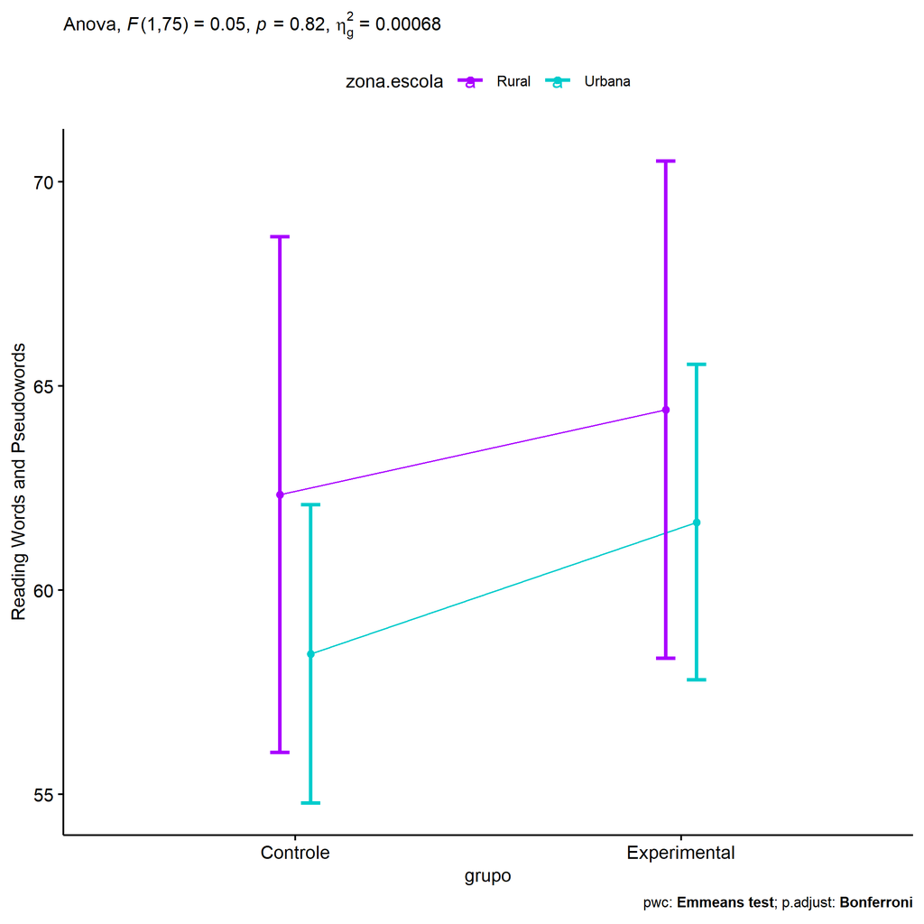

```r
if (length(unique(pdat[["zona.escola"]])) >= 2) {
  ggPlotAoC2(pwcs, "grupo", "zona.escola", aov, ylab = "Reading Words and Pseudowords",
             subtitle = which(aov$Effect == "grupo:zona.escola"), addParam = "errorbar") +
    ggplot2::scale_color_manual(values = color[["zona.escola"]]) +
    ggplot2::ylab("Reading Words and Pseudowords") +
    if (ymin.ci < ymax.ci) ggplot2::ylim(ymin.ci, ymax.ci)
}
```

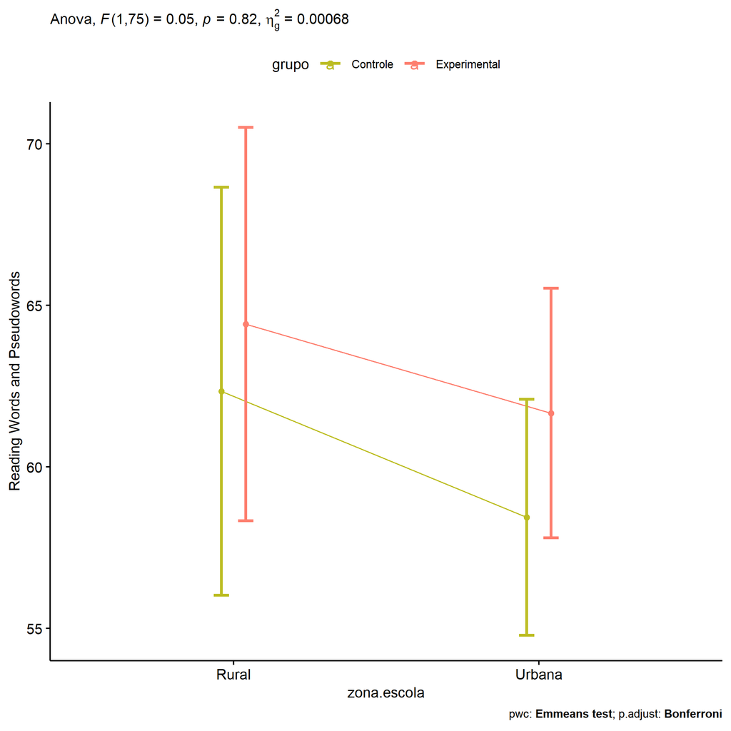

```r
if (length(unique(pdat[["zona.escola"]])) >= 2) {
  ggPlotAoC2(pwcs, "zona.escola", "grupo", aov, ylab = "Reading Words and Pseudowords",
               subtitle = which(aov$Effect == "grupo:zona.escola"), addParam = "errorbar") +
    ggplot2::scale_color_manual(values = color[["grupo"]]) +
    ggplot2::ylab("Reading Words and Pseudowords") +
    if (ymin.ci < ymax.ci) ggplot2::ylim(ymin.ci, ymax.ci)
}
```

```r
if (length(unique(pdat[["zona.escola"]])) >= 2) {
  plots <- twoWayAncovaBoxPlots(
    wdat, "score.CLPP.pos", c("grupo","zona.escola"), aov, pwcs, covar = "score.CLPP.pre",
    theme = "classic", color = color[["grupo:zona.escola"]],
    subtitle = which(aov$Effect == "grupo:zona.escola"))
}
```

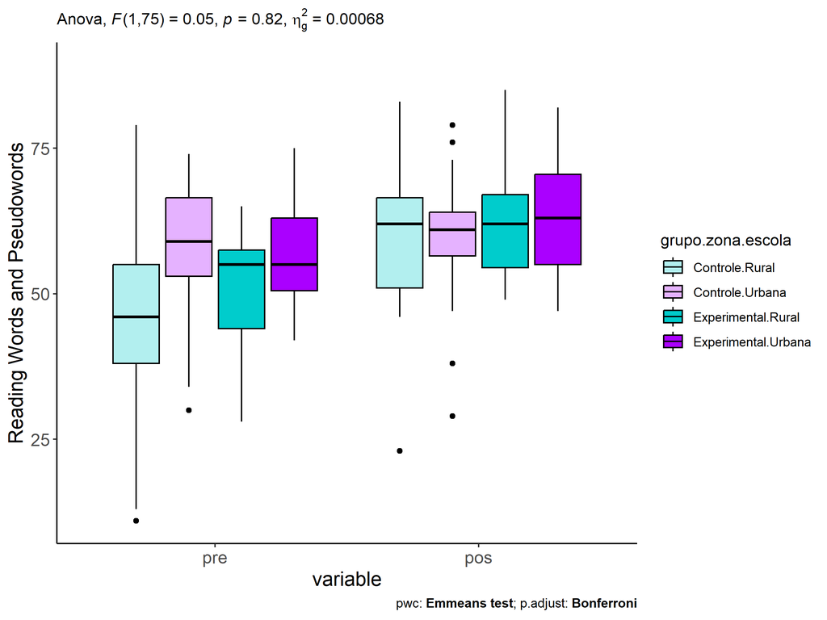

```r
if (length(unique(pdat[["zona.escola"]])) >= 2) {
  plots[["grupo:zona.escola"]] + ggplot2::ylab("Reading Words and Pseudowords") +
  ggplot2::scale_x_discrete(labels=c('pre', 'pos')) +
  if (ymin < ymax) ggplot2::ylim(ymin, ymax)
}
```

```r
if (length(unique(pdat[["zona.escola"]])) >= 2) {
  plots <- twoWayAncovaBoxPlots(
    wdat.long, "score.CLPP", c("grupo","zona.escola"), aov, pwc.long,
    pre.post = "time",
    theme = "classic", color = color$prepost)
}
```

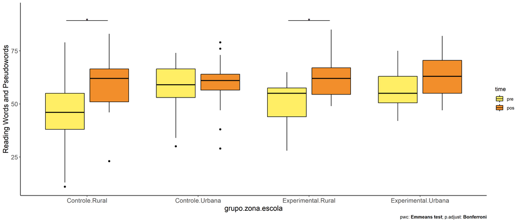

```r
if (length(unique(pdat[["zona.escola"]])) >= 2)
  plots[["grupo:zona.escola"]] + ggplot2::ylab("Reading Words and Pseudowords") +
    if (ymin < ymax) ggplot2::ylim(ymin, ymax)
```

### Checking linearity assumption

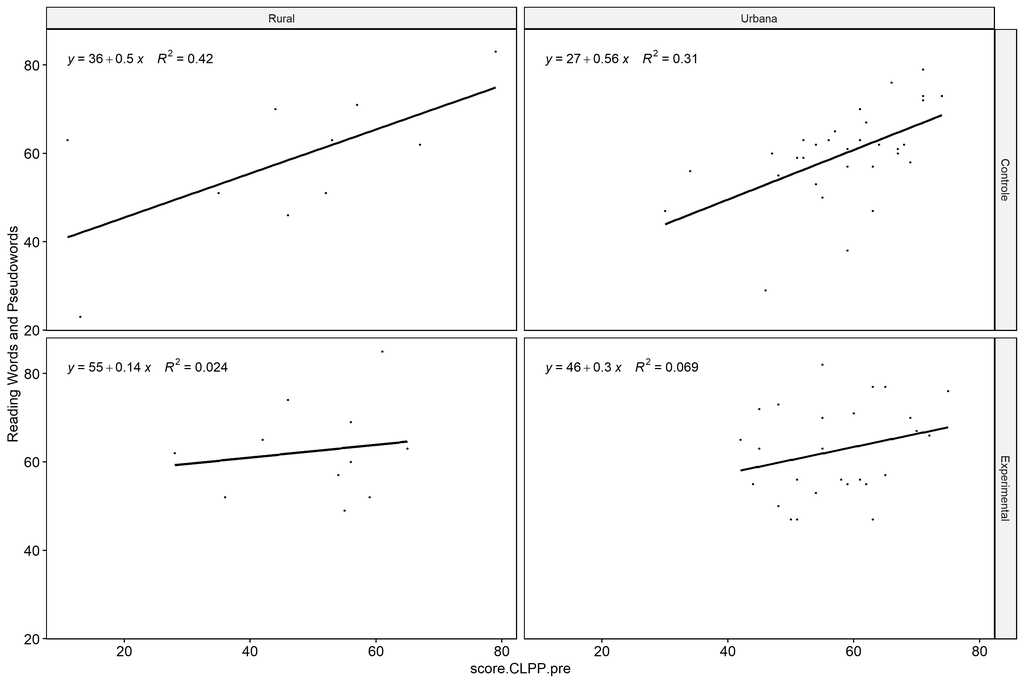

```r
if (length(unique(pdat[["zona.escola"]])) >= 2) {
  ggscatter(wdat, x = "score.CLPP.pre", y = "score.CLPP.pos", size = 0.5,
            facet.by = c("grupo","zona.escola"), add = "reg.line")+
    stat_regline_equation(
      aes(label =  paste(..eq.label.., ..rr.label.., sep = "~~~~"))
    ) + ggplot2::ylab("Reading Words and Pseudowords") +
    if (ymin < ymax) ggplot2::ylim(ymin, ymax)
}
```

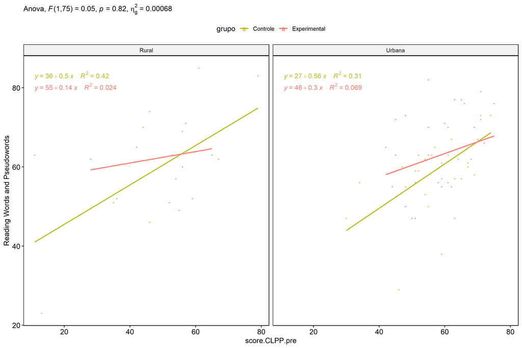

```r
if (length(unique(pdat[["zona.escola"]])) >= 2) {
  ggscatter(wdat, x = "score.CLPP.pre", y = "score.CLPP.pos", size = 0.5,
            color = "grupo", facet.by = "zona.escola", add = "reg.line")+
    stat_regline_equation(
      aes(label =  paste(..eq.label.., ..rr.label.., sep = "~~~~"), color = grupo)
    ) +
    ggplot2::labs(subtitle = rstatix::get_test_label(aov, detailed = T, row = which(aov$Effect == "grupo:zona.escola"))) +
    ggplot2::scale_color_manual(values = color[["grupo"]]) +
    ggplot2::ylab("Reading Words and Pseudowords") +
    if (ymin < ymax) ggplot2::ylim(ymin, ymax)
}
```

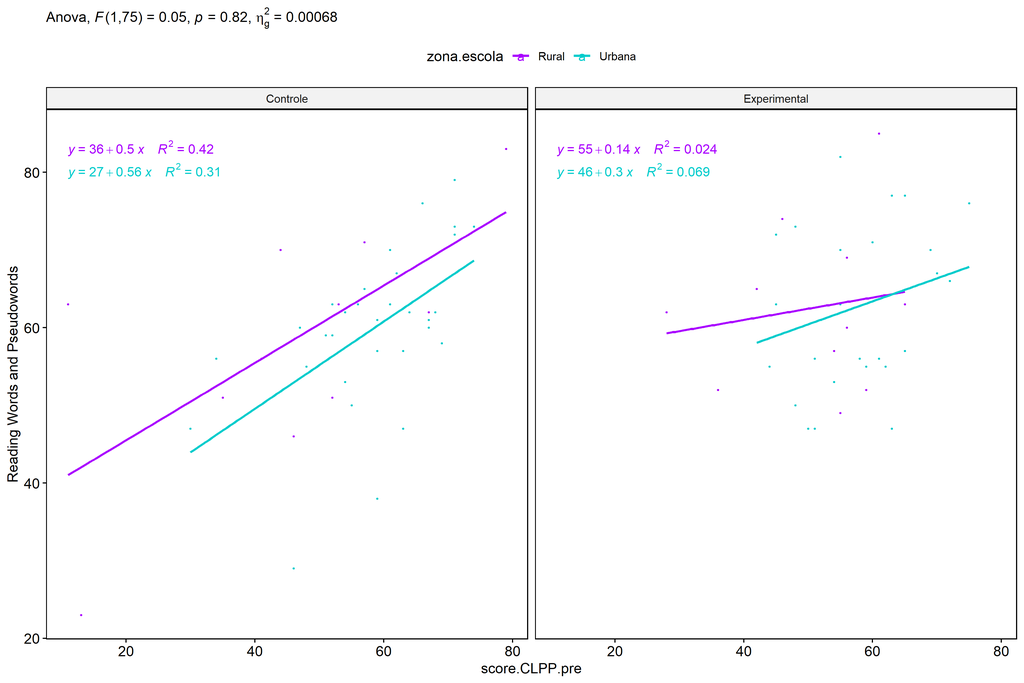

```r
if (length(unique(pdat[["zona.escola"]])) >= 2) {
  ggscatter(wdat, x = "score.CLPP.pre", y = "score.CLPP.pos", size = 0.5,
            color = "zona.escola", facet.by = "grupo", add = "reg.line")+
    stat_regline_equation(
      aes(label =  paste(..eq.label.., ..rr.label.., sep = "~~~~"), color = zona.escola)
    ) +
    ggplot2::labs(subtitle = rstatix::get_test_label(aov, detailed = T, row = which(aov$Effect == "grupo:zona.escola"))) +
    ggplot2::scale_color_manual(values = color[["zona.escola"]]) +
    ggplot2::ylab("Reading Words and Pseudowords") +
    if (ymin < ymax) ggplot2::ylim(ymin, ymax)
}
```

### Checking normality and homogeneity

```r
if (length(unique(pdat[["zona.escola"]])) >= 2)
  res <- augment(lm(score.CLPP.pos ~ score.CLPP.pre + grupo*zona.escola, data = wdat))
```

```r
if (length(unique(pdat[["zona.escola"]])) >= 2)
  shapiro_test(res$.resid)
```

```
## # A tibble: 1 × 3
##   variable   statistic p.value
##   <chr>          <dbl>   <dbl>
## 1 res$.resid     0.991   0.828
```

```r
if (length(unique(pdat[["zona.escola"]])) >= 2)
  levene_test(res, .resid ~ grupo*zona.escola)
```

```
## # A tibble: 1 × 4
##     df1   df2 statistic     p
##   <int> <int>     <dbl> <dbl>
## 1     3    76     0.992 0.401
```

# ANCOVA and Pairwise for two factors **grupo:score.CLPP.quintile**

## Without remove non-normal data

```r
pdat = remove_group_data(dat[!is.na(dat[["grupo"]]) & !is.na(dat[["score.CLPP.quintile"]]),],
                         "score.CLPP.pos", c("grupo","score.CLPP.quintile"))
pdat = pdat[pdat[["score.CLPP.quintile"]] %in% do.call(
  intersect, lapply(unique(pdat[["grupo"]]), FUN = function(x) {
    unique(pdat[["score.CLPP.quintile"]][which(pdat[["grupo"]] == x)])
  })),]
pdat[["grupo"]] = factor(pdat[["grupo"]], level[["grupo"]])
pdat[["score.CLPP.quintile"]] = factor(
  pdat[["score.CLPP.quintile"]],
  level[["score.CLPP.quintile"]][level[["score.CLPP.quintile"]] %in% unique(pdat[["score.CLPP.quintile"]])])

pdat.long <- rbind(pdat[,c("id","grupo","score.CLPP.quintile")], pdat[,c("id","grupo","score.CLPP.quintile")])
pdat.long[["time"]] <- c(rep("pre", nrow(pdat)), rep("pos", nrow(pdat)))
pdat.long[["time"]] <- factor(pdat.long[["time"]], c("pre","pos"))
pdat.long[["score.CLPP"]] <- c(pdat[["score.CLPP.pre"]], pdat[["score.CLPP.pos"]])

if (length(unique(pdat[["score.CLPP.quintile"]])) >= 2) {
  aov = anova_test(pdat, score.CLPP.pos ~ score.CLPP.pre + grupo*score.CLPP.quintile)
  laov[["grupo:score.CLPP.quintile"]] <- get_anova_table(aov)
}
```

```r
if (length(unique(pdat[["score.CLPP.quintile"]])) >= 2) {
  pwcs <- list()
  pwcs[["score.CLPP.quintile"]] <- emmeans_test(
    group_by(pdat, grupo), score.CLPP.pos ~ score.CLPP.quintile,
    covariate = score.CLPP.pre, p.adjust.method = "bonferroni")
  pwcs[["grupo"]] <- emmeans_test(
    group_by(pdat, score.CLPP.quintile), score.CLPP.pos ~ grupo,
    covariate = score.CLPP.pre, p.adjust.method = "bonferroni")

  pwc <- plyr::rbind.fill(pwcs[["grupo"]], pwcs[["score.CLPP.quintile"]])
  pwc <- pwc[,c("grupo","score.CLPP.quintile", colnames(pwc)[!colnames(pwc) %in% c("grupo","score.CLPP.quintile")])]
}
```

```r
if (length(unique(pdat[["score.CLPP.quintile"]])) >= 2) {
  pwc.long <- emmeans_test(dplyr::group_by_at(pdat.long, c("grupo","score.CLPP.quintile")),
                           score.CLPP ~ time,
                           p.adjust.method = "bonferroni")
  lpwc[["grupo:score.CLPP.quintile"]] <- plyr::rbind.fill(pwc, pwc.long)
}
```

```r
if (length(unique(pdat[["score.CLPP.quintile"]])) >= 2) {
  ds <- get.descriptives(pdat, "score.CLPP.pos", c("grupo","score.CLPP.quintile"), covar = "score.CLPP.pre")
  ds <- merge(ds[ds$variable != "score.CLPP.pre",],
              ds[ds$variable == "score.CLPP.pre", !colnames(ds) %in% c("variable")],
              by = c("grupo","score.CLPP.quintile"), all.x = T, suffixes = c("", ".score.CLPP.pre"))
  ds <- merge(get_emmeans(pwcs[["grupo"]]), ds,
              by = c("grupo","score.CLPP.quintile"), suffixes = c(".emms", ""))
  ds <- ds[,c("grupo","score.CLPP.quintile","n","mean.score.CLPP.pre","se.score.CLPP.pre","mean","se",
              "emmean","se.emms","conf.low","conf.high")]

  colnames(ds) <- c("grupo","score.CLPP.quintile", "N", paste0(c("M","SE")," (pre)"),
                    paste0(c("M","SE"), " (unadj)"),
                    paste0(c("M", "SE"), " (adj)"), "conf.low", "conf.high")

  lemms[["grupo:score.CLPP.quintile"]] <- ds
}
```

## Computing ANCOVA and PairWise After removing non-normal data (OK)

```r
if (length(unique(pdat[["score.CLPP.quintile"]])) >= 2) {
  wdat = pdat

  res = residuals(lm(score.CLPP.pos ~ score.CLPP.pre + grupo*score.CLPP.quintile, data = wdat))
  non.normal = getNonNormal(res, wdat$id, plimit = 0.05)

  wdat = wdat[!wdat$id %in% non.normal,]

  wdat.long <- rbind(wdat[,c("id","grupo","score.CLPP.quintile")], wdat[,c("id","grupo","score.CLPP.quintile")])
  wdat.long[["time"]] <- c(rep("pre", nrow(wdat)), rep("pos", nrow(wdat)))
  wdat.long[["time"]] <- factor(wdat.long[["time"]], c("pre","pos"))
  wdat.long[["score.CLPP"]] <- c(wdat[["score.CLPP.pre"]], wdat[["score.CLPP.pos"]])


  ldat[["grupo:score.CLPP.quintile"]] = wdat

  (non.normal)
}
```

```r
if (length(unique(pdat[["score.CLPP.quintile"]])) >= 2) {
  aov = anova_test(wdat, score.CLPP.pos ~ score.CLPP.pre + grupo*score.CLPP.quintile)
  laov[["grupo:score.CLPP.quintile"]] <- merge(get_anova_table(aov), laov[["grupo:score.CLPP.quintile"]],
                                         by="Effect", suffixes = c("","'"))
  df = get_anova_table(aov)
}
```

| Effect | DFn | DFd | F | p | p<.05 | ges |
| --- | --- | --- | --- | --- | --- | --- |
| score.CLPP.pre | 1 | 57 | 0.031 | 0.862 |  | 0.001 |
| grupo | 1 | 57 | 2.034 | 0.159 |  | 0.034 |
| score.CLPP.quintile | 1 | 57 | 0.386 | 0.537 |  | 0.007 |
| grupo:score.CLPP.quintile | 1 | 57 | 0.663 | 0.419 |  | 0.012 |

```r
if (length(unique(pdat[["score.CLPP.quintile"]])) >= 2) {
  pwcs <- list()
  pwcs[["score.CLPP.quintile"]] <- emmeans_test(
    group_by(wdat, grupo), score.CLPP.pos ~ score.CLPP.quintile,
    covariate = score.CLPP.pre, p.adjust.method = "bonferroni")
  pwcs[["grupo"]] <- emmeans_test(
    group_by(wdat, score.CLPP.quintile), score.CLPP.pos ~ grupo,
    covariate = score.CLPP.pre, p.adjust.method = "bonferroni")

  pwc <- plyr::rbind.fill(pwcs[["grupo"]], pwcs[["score.CLPP.quintile"]])
  pwc <- pwc[,c("grupo","score.CLPP.quintile", colnames(pwc)[!colnames(pwc) %in% c("grupo","score.CLPP.quintile")])]
}
```

| grupo | score.CLPP.quintile | term | .y. | group1 | group2 | df | statistic | p | p.adj | p.adj.signif |
| --- | --- | --- | --- | --- | --- | --- | --- | --- | --- | --- |
|  | 2nd quintile | score.CLPP.pre*grupo | score.CLPP.pos | Controle | Experimental | 57 | -1.585 | 0.119 | 0.119 | ns |
|  | 3rd quintile | score.CLPP.pre*grupo | score.CLPP.pos | Controle | Experimental | 57 | -0.442 | 0.660 | 0.660 | ns |
| Controle |  | score.CLPP.pre*score.CLPP.quintile | score.CLPP.pos | 2nd quintile | 3rd quintile | 57 | -0.951 | 0.346 | 0.346 | ns |
| Experimental |  | score.CLPP.pre*score.CLPP.quintile | score.CLPP.pos | 2nd quintile | 3rd quintile | 57 | -0.182 | 0.856 | 0.856 | ns |

```r
if (length(unique(pdat[["score.CLPP.quintile"]])) >= 2) {
  pwc.long <- emmeans_test(dplyr::group_by_at(wdat.long, c("grupo","score.CLPP.quintile")),
                           score.CLPP ~ time,
                           p.adjust.method = "bonferroni")
  lpwc[["grupo:score.CLPP.quintile"]] <- merge(plyr::rbind.fill(pwc, pwc.long),
                                         lpwc[["grupo:score.CLPP.quintile"]],
                                         by=c("grupo","score.CLPP.quintile","term",".y.","group1","group2"),
                                         suffixes = c("","'"))
}
```

| grupo | score.CLPP.quintile | term | .y. | group1 | group2 | df | statistic | p | p.adj | p.adj.signif |
| --- | --- | --- | --- | --- | --- | --- | --- | --- | --- | --- |
| Controle | 2nd quintile | time | score.CLPP | pre | pos | 116 | -1.690 | 0.094 | 0.094 | ns |
| Controle | 3rd quintile | time | score.CLPP | pre | pos | 116 | 0.313 | 0.754 | 0.754 | ns |
| Experimental | 2nd quintile | time | score.CLPP | pre | pos | 116 | -4.570 | 0.000 | 0.000 | **** |
| Experimental | 3rd quintile | time | score.CLPP | pre | pos | 116 | -0.666 | 0.507 | 0.507 | ns |

```r
if (length(unique(pdat[["score.CLPP.quintile"]])) >= 2) {
  ds <- get.descriptives(wdat, "score.CLPP.pos", c("grupo","score.CLPP.quintile"), covar = "score.CLPP.pre")
  ds <- merge(ds[ds$variable != "score.CLPP.pre",],
              ds[ds$variable == "score.CLPP.pre", !colnames(ds) %in% c("variable")],
              by = c("grupo","score.CLPP.quintile"), all.x = T, suffixes = c("", ".score.CLPP.pre"))
  ds <- merge(get_emmeans(pwcs[["grupo"]]), ds,
              by = c("grupo","score.CLPP.quintile"), suffixes = c(".emms", ""))
  ds <- ds[,c("grupo","score.CLPP.quintile","n","mean.score.CLPP.pre","se.score.CLPP.pre",
              "mean","se","emmean","se.emms","conf.low","conf.high")]

  colnames(ds) <- c("grupo","score.CLPP.quintile", "N", paste0(c("M","SE")," (pre)"),
                    paste0(c("M","SE"), " (unadj)"),
                    paste0(c("M", "SE"), " (adj)"), "conf.low", "conf.high")

  lemms[["grupo:score.CLPP.quintile"]] <- merge(ds, lemms[["grupo:score.CLPP.quintile"]],
                                          by=c("grupo","score.CLPP.quintile"), suffixes = c("","'"))
}
```

| grupo | score.CLPP.quintile | N | M (pre) | SE (pre) | M (unadj) | SE (unadj) | M (adj) | SE (adj) | conf.low | conf.high |
| --- | --- | --- | --- | --- | --- | --- | --- | --- | --- | --- |
| Controle | 2nd quintile | 13 | 50.308 | 1.009 | 55.385 | 2.841 | 55.705 | 3.365 | 48.968 | 62.443 |
| Controle | 3rd quintile | 17 | 62.118 | 0.954 | 61.294 | 2.123 | 60.916 | 3.281 | 54.346 | 67.486 |
| Experimental | 2nd quintile | 18 | 49.556 | 1.103 | 61.222 | 2.421 | 61.587 | 3.179 | 55.221 | 67.954 |
| Experimental | 3rd quintile | 14 | 60.929 | 0.829 | 62.857 | 2.987 | 62.549 | 3.239 | 56.063 | 69.035 |

### Plots for ancova

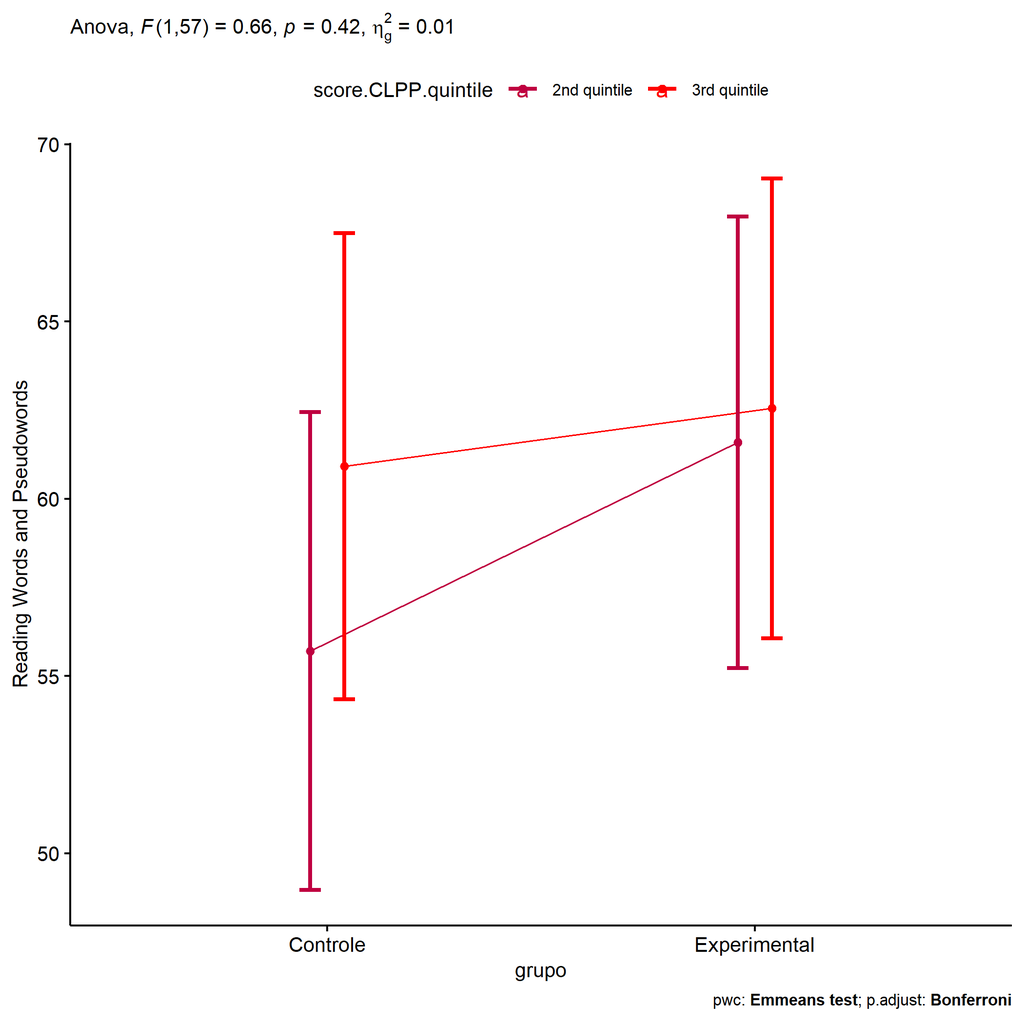

```r
if (length(unique(pdat[["score.CLPP.quintile"]])) >= 2) {
  ggPlotAoC2(pwcs, "grupo", "score.CLPP.quintile", aov, ylab = "Reading Words and Pseudowords",
             subtitle = which(aov$Effect == "grupo:score.CLPP.quintile"), addParam = "errorbar") +
    ggplot2::scale_color_manual(values = color[["score.CLPP.quintile"]]) +
    ggplot2::ylab("Reading Words and Pseudowords") +
    if (ymin.ci < ymax.ci) ggplot2::ylim(ymin.ci, ymax.ci)
}
```

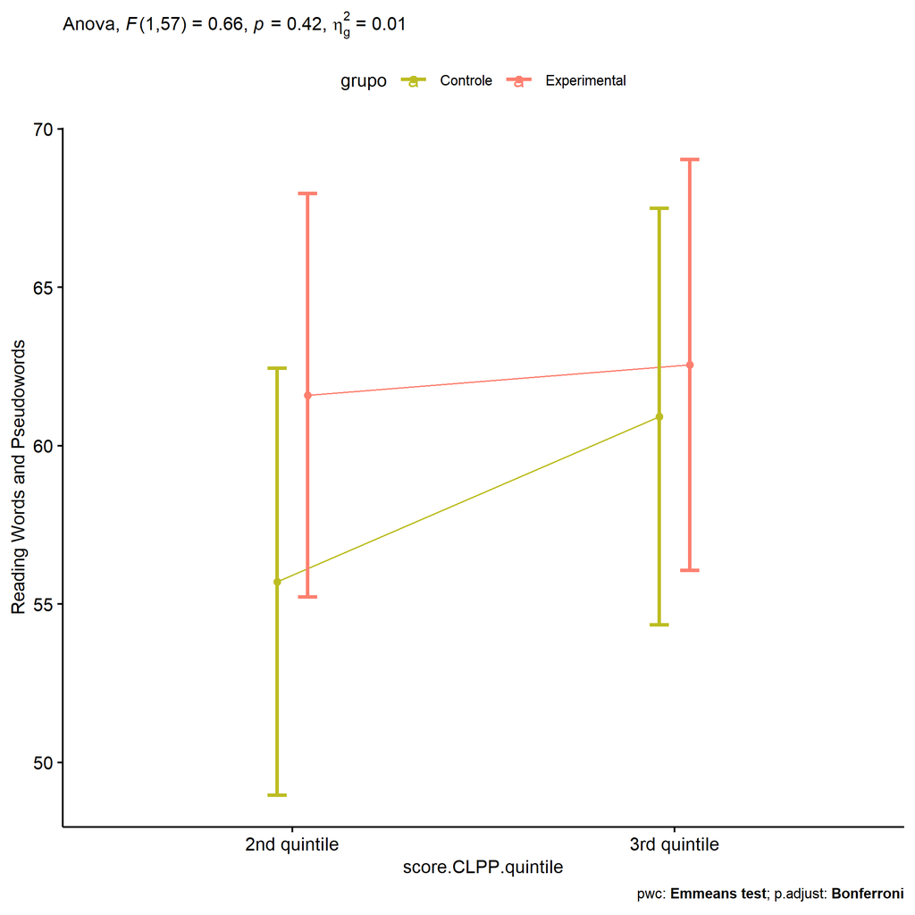

```r
if (length(unique(pdat[["score.CLPP.quintile"]])) >= 2) {
  ggPlotAoC2(pwcs, "score.CLPP.quintile", "grupo", aov, ylab = "Reading Words and Pseudowords",
               subtitle = which(aov$Effect == "grupo:score.CLPP.quintile"), addParam = "errorbar") +
    ggplot2::scale_color_manual(values = color[["grupo"]]) +
    ggplot2::ylab("Reading Words and Pseudowords") +
    if (ymin.ci < ymax.ci) ggplot2::ylim(ymin.ci, ymax.ci)
}
```

```r
if (length(unique(pdat[["score.CLPP.quintile"]])) >= 2) {
  plots <- twoWayAncovaBoxPlots(
    wdat, "score.CLPP.pos", c("grupo","score.CLPP.quintile"), aov, pwcs, covar = "score.CLPP.pre",
    theme = "classic", color = color[["grupo:score.CLPP.quintile"]],
    subtitle = which(aov$Effect == "grupo:score.CLPP.quintile"))
}
```

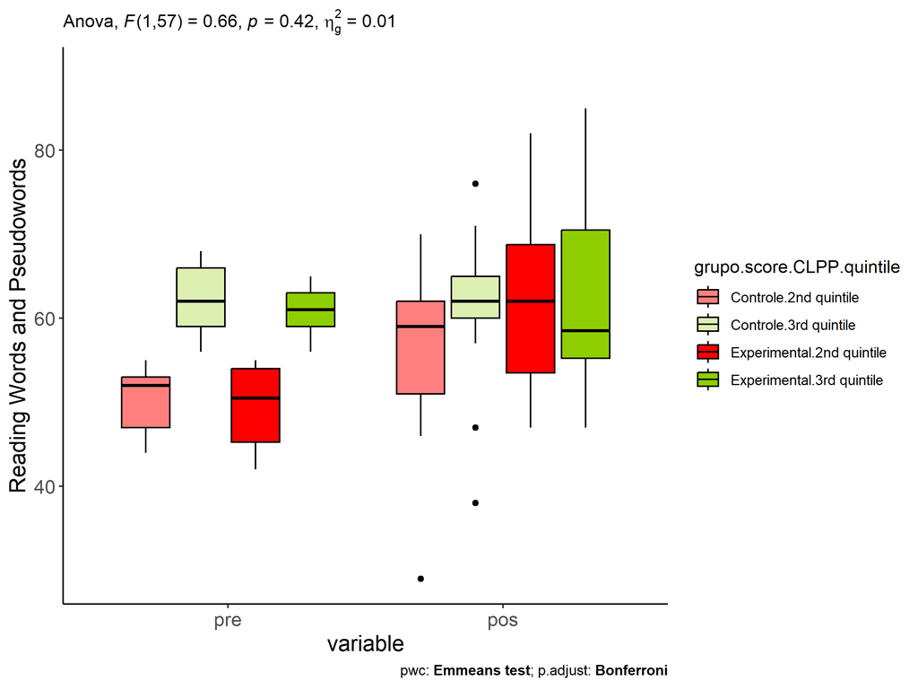

```r
if (length(unique(pdat[["score.CLPP.quintile"]])) >= 2) {
  plots[["grupo:score.CLPP.quintile"]] + ggplot2::ylab("Reading Words and Pseudowords") +
  ggplot2::scale_x_discrete(labels=c('pre', 'pos')) +
  if (ymin < ymax) ggplot2::ylim(ymin, ymax)
}
```

```r
if (length(unique(pdat[["score.CLPP.quintile"]])) >= 2) {
  plots <- twoWayAncovaBoxPlots(
    wdat.long, "score.CLPP", c("grupo","score.CLPP.quintile"), aov, pwc.long,
    pre.post = "time",
    theme = "classic", color = color$prepost)
}
```

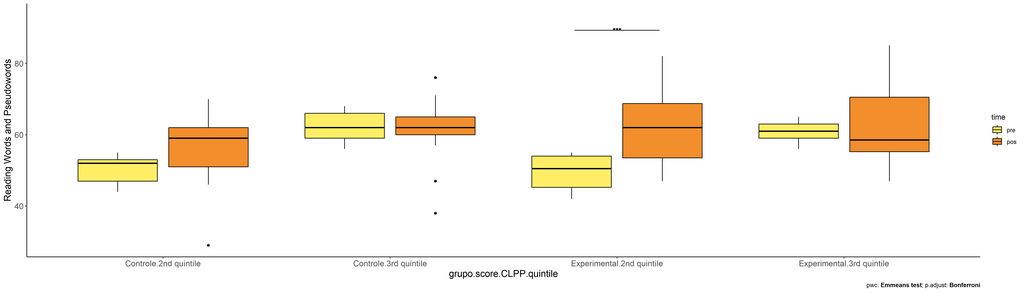

```r
if (length(unique(pdat[["score.CLPP.quintile"]])) >= 2)
  plots[["grupo:score.CLPP.quintile"]] + ggplot2::ylab("Reading Words and Pseudowords") +
    if (ymin < ymax) ggplot2::ylim(ymin, ymax)
```

### Checking linearity assumption

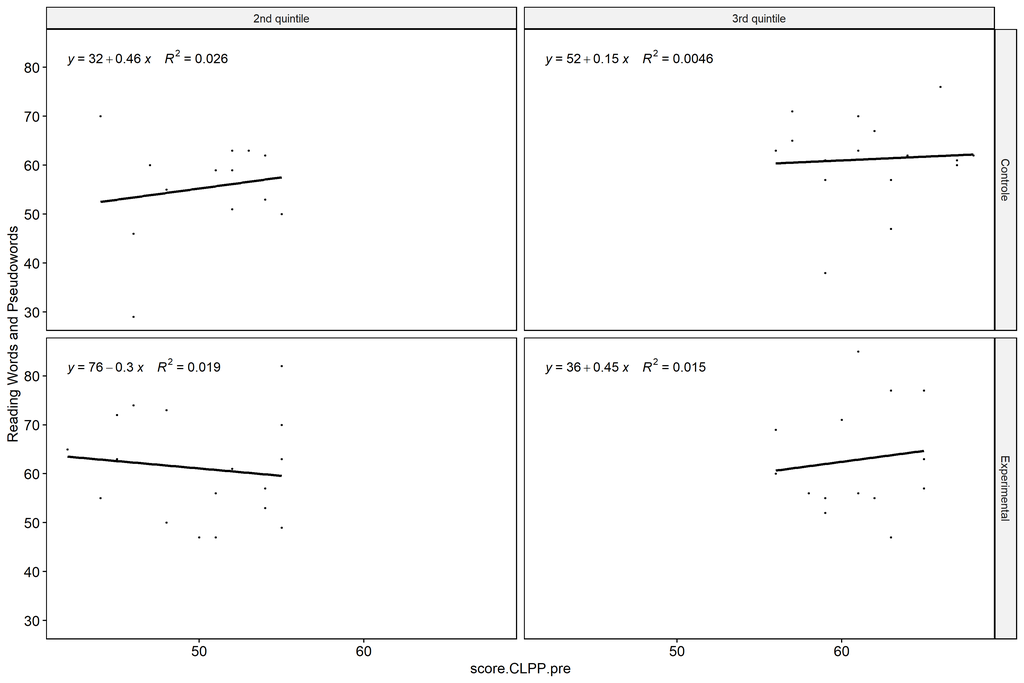

```r
if (length(unique(pdat[["score.CLPP.quintile"]])) >= 2) {
  ggscatter(wdat, x = "score.CLPP.pre", y = "score.CLPP.pos", size = 0.5,
            facet.by = c("grupo","score.CLPP.quintile"), add = "reg.line")+
    stat_regline_equation(
      aes(label =  paste(..eq.label.., ..rr.label.., sep = "~~~~"))
    ) + ggplot2::ylab("Reading Words and Pseudowords") +
    if (ymin < ymax) ggplot2::ylim(ymin, ymax)
}
```

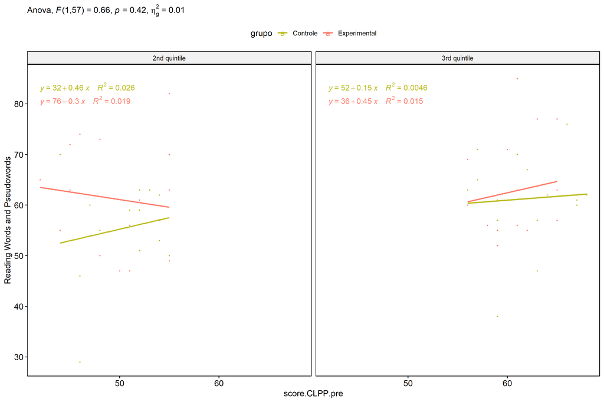

```r
if (length(unique(pdat[["score.CLPP.quintile"]])) >= 2) {
  ggscatter(wdat, x = "score.CLPP.pre", y = "score.CLPP.pos", size = 0.5,
            color = "grupo", facet.by = "score.CLPP.quintile", add = "reg.line")+
    stat_regline_equation(
      aes(label =  paste(..eq.label.., ..rr.label.., sep = "~~~~"), color = grupo)
    ) +
    ggplot2::labs(subtitle = rstatix::get_test_label(aov, detailed = T, row = which(aov$Effect == "grupo:score.CLPP.quintile"))) +
    ggplot2::scale_color_manual(values = color[["grupo"]]) +
    ggplot2::ylab("Reading Words and Pseudowords") +
    if (ymin < ymax) ggplot2::ylim(ymin, ymax)
}
```

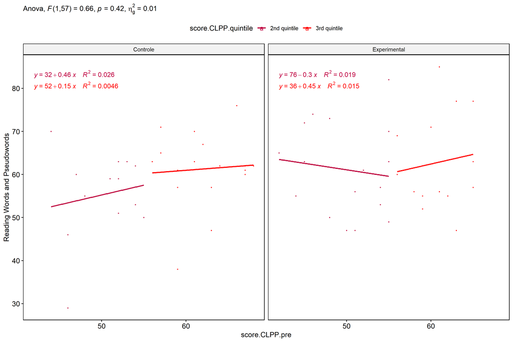

```r
if (length(unique(pdat[["score.CLPP.quintile"]])) >= 2) {
  ggscatter(wdat, x = "score.CLPP.pre", y = "score.CLPP.pos", size = 0.5,
            color = "score.CLPP.quintile", facet.by = "grupo", add = "reg.line")+
    stat_regline_equation(
      aes(label =  paste(..eq.label.., ..rr.label.., sep = "~~~~"), color = score.CLPP.quintile)
    ) +
    ggplot2::labs(subtitle = rstatix::get_test_label(aov, detailed = T, row = which(aov$Effect == "grupo:score.CLPP.quintile"))) +
    ggplot2::scale_color_manual(values = color[["score.CLPP.quintile"]]) +
    ggplot2::ylab("Reading Words and Pseudowords") +
    if (ymin < ymax) ggplot2::ylim(ymin, ymax)
}
```

### Checking normality and homogeneity

```r
if (length(unique(pdat[["score.CLPP.quintile"]])) >= 2)
  res <- augment(lm(score.CLPP.pos ~ score.CLPP.pre + grupo*score.CLPP.quintile, data = wdat))
```

```r
if (length(unique(pdat[["score.CLPP.quintile"]])) >= 2)
  shapiro_test(res$.resid)
```

```
## # A tibble: 1 × 3
##   variable   statistic p.value
##   <chr>          <dbl>   <dbl>
## 1 res$.resid     0.992   0.969
```

```r
if (length(unique(pdat[["score.CLPP.quintile"]])) >= 2)
  levene_test(res, .resid ~ grupo*score.CLPP.quintile)
```

```
## # A tibble: 1 × 4
##     df1   df2 statistic     p
##   <int> <int>     <dbl> <dbl>
## 1     3    58     0.766 0.518
```

# Summary of Results

## Descriptive Statistics

```r
df <- get.descriptives(ldat[["grupo"]], c(dv.pre, dv.pos), c("grupo"),
                       include.global = T, symmetry.test = T, normality.test = F)
df <- plyr::rbind.fill(
  df, do.call(plyr::rbind.fill, lapply(lfatores2, FUN = function(f) {
    if (nrow(dat) > 0 && sum(!is.na(unique(dat[[f]]))) > 1 && paste0("grupo:",f) %in% names(ldat))
      get.descriptives(ldat[[paste0("grupo:",f)]], c(dv.pre,dv.pos), c("grupo", f),
                       symmetry.test = T, normality.test = F)
    }))
)
df <- df[,c(fatores1[fatores1 %in% colnames(df)],"variable",
             colnames(df)[!colnames(df) %in% c(fatores1,"variable")])]
```

| grupo | genero | zona.participante | zona.escola | score.CLPP.quintile | variable | n | mean | median | min | max | sd | se | ci | iqr | symmetry | skewness | kurtosis |
| --- | --- | --- | --- | --- | --- | --- | --- | --- | --- | --- | --- | --- | --- | --- | --- | --- | --- |
| Controle |  |  |  |  | score.CLPP.pre | 42 | 54.976 | 57.0 | 11 | 79 | 14.665 | 2.263 | 4.570 | 16.75 | NO | -1.139 | 1.369 |
| Experimental |  |  |  |  | score.CLPP.pre | 38 | 55.132 | 55.0 | 28 | 75 | 10.030 | 1.627 | 3.297 | 13.25 | YES | -0.347 | -0.011 |
|  |  |  |  |  | score.CLPP.pre | 80 | 55.050 | 56.0 | 11 | 79 | 12.599 | 1.409 | 2.804 | 15.00 | NO | -1.033 | 1.801 |
| Controle |  |  |  |  | score.CLPP.pos | 42 | 59.429 | 61.0 | 23 | 83 | 11.906 | 1.837 | 3.710 | 9.25 | NO | -0.820 | 1.267 |
| Experimental |  |  |  |  | score.CLPP.pos | 38 | 62.500 | 62.5 | 47 | 85 | 10.173 | 1.650 | 3.344 | 15.00 | YES | 0.290 | -0.901 |
|  |  |  |  |  | score.CLPP.pos | 80 | 60.888 | 61.5 | 23 | 85 | 11.155 | 1.247 | 2.482 | 14.25 | YES | -0.481 | 1.040 |
| Controle | F |  |  |  | score.CLPP.pre | 22 | 57.136 | 59.0 | 13 | 79 | 14.685 | 3.131 | 6.511 | 15.75 | NO | -1.121 | 1.454 |
| Controle | M |  |  |  | score.CLPP.pre | 20 | 52.600 | 56.0 | 11 | 71 | 14.641 | 3.274 | 6.852 | 15.50 | NO | -1.164 | 0.965 |
| Experimental | F |  |  |  | score.CLPP.pre | 17 | 58.941 | 61.0 | 42 | 72 | 9.162 | 2.222 | 4.710 | 10.00 | YES | -0.468 | -1.053 |
| Experimental | M |  |  |  | score.CLPP.pre | 21 | 52.048 | 54.0 | 28 | 75 | 9.831 | 2.145 | 4.475 | 10.00 | YES | -0.250 | 0.646 |
| Controle | F |  |  |  | score.CLPP.pos | 22 | 60.455 | 61.0 | 23 | 83 | 12.678 | 2.703 | 5.621 | 9.00 | NO | -0.948 | 1.682 |
| Controle | M |  |  |  | score.CLPP.pos | 20 | 58.300 | 61.0 | 29 | 76 | 11.211 | 2.507 | 5.247 | 12.75 | NO | -0.637 | 0.147 |
| Experimental | F |  |  |  | score.CLPP.pos | 17 | 65.235 | 66.0 | 47 | 85 | 10.121 | 2.455 | 5.204 | 10.00 | YES | -0.141 | -0.585 |
| Experimental | M |  |  |  | score.CLPP.pos | 21 | 60.286 | 56.0 | 47 | 82 | 9.900 | 2.160 | 4.507 | 12.00 | NO | 0.664 | -0.830 |
| Controle |  | Rural |  |  | score.CLPP.pre | 11 | 55.818 | 52.0 | 41 | 69 | 10.591 | 3.193 | 7.115 | 20.00 | YES | 0.014 | -1.851 |
| Controle |  | Urbana |  |  | score.CLPP.pre | 21 | 57.048 | 59.0 | 13 | 79 | 15.279 | 3.334 | 6.955 | 12.00 | NO | -1.129 | 1.136 |
| Experimental |  | Rural |  |  | score.CLPP.pre | 14 | 58.714 | 61.5 | 28 | 75 | 11.964 | 3.198 | 6.908 | 9.50 | NO | -0.962 | 0.626 |
| Experimental |  | Urbana |  |  | score.CLPP.pre | 14 | 53.071 | 53.0 | 42 | 69 | 7.810 | 2.087 | 4.509 | 7.75 | YES | 0.478 | -0.802 |
| Controle |  | Rural |  |  | score.CLPP.pos | 11 | 58.636 | 60.0 | 46 | 70 | 6.516 | 1.965 | 4.377 | 7.00 | YES | -0.277 | -0.645 |
| Controle |  | Urbana |  |  | score.CLPP.pos | 21 | 61.524 | 62.0 | 23 | 83 | 13.927 | 3.039 | 6.340 | 16.00 | NO | -0.891 | 0.732 |
| Experimental |  | Rural |  |  | score.CLPP.pos | 14 | 64.571 | 64.0 | 47 | 85 | 12.829 | 3.429 | 7.407 | 20.00 | YES | 0.069 | -1.479 |
| Experimental |  | Urbana |  |  | score.CLPP.pos | 14 | 64.000 | 67.0 | 47 | 77 | 9.438 | 2.522 | 5.449 | 14.25 | YES | -0.459 | -1.307 |
| Controle |  |  | Rural |  | score.CLPP.pre | 11 | 45.273 | 46.0 | 11 | 79 | 20.480 | 6.175 | 13.758 | 17.00 | YES | -0.254 | -0.924 |
| Controle |  |  | Urbana |  | score.CLPP.pre | 31 | 58.419 | 59.0 | 30 | 74 | 10.359 | 1.861 | 3.800 | 13.50 | NO | -0.849 | 0.471 |
| Experimental |  |  | Rural |  | score.CLPP.pre | 11 | 50.727 | 55.0 | 28 | 65 | 11.376 | 3.430 | 7.643 | 13.50 | NO | -0.663 | -0.940 |
| Experimental |  |  | Urbana |  | score.CLPP.pre | 27 | 56.926 | 55.0 | 42 | 75 | 9.047 | 1.741 | 3.579 | 12.50 | YES | 0.193 | -1.024 |
| Controle |  |  | Rural |  | score.CLPP.pos | 11 | 58.091 | 62.0 | 23 | 83 | 15.732 | 4.743 | 10.569 | 15.50 | NO | -0.610 | -0.066 |
| Controle |  |  | Urbana |  | score.CLPP.pos | 31 | 59.903 | 61.0 | 29 | 79 | 10.505 | 1.887 | 3.853 | 7.50 | NO | -0.746 | 0.986 |
| Experimental |  |  | Rural |  | score.CLPP.pos | 11 | 62.545 | 62.0 | 49 | 85 | 10.615 | 3.200 | 7.131 | 12.50 | NO | 0.615 | -0.618 |
| Experimental |  |  | Urbana |  | score.CLPP.pos | 27 | 62.481 | 63.0 | 47 | 82 | 10.196 | 1.962 | 4.033 | 15.50 | YES | 0.122 | -1.216 |
| Controle |  |  |  | 2nd quintile | score.CLPP.pre | 13 | 50.308 | 52.0 | 44 | 55 | 3.637 | 1.009 | 2.198 | 6.00 | YES | -0.353 | -1.526 |
| Controle |  |  |  | 3rd quintile | score.CLPP.pre | 17 | 62.118 | 62.0 | 56 | 68 | 3.935 | 0.954 | 2.023 | 7.00 | YES | 0.028 | -1.479 |
| Experimental |  |  |  | 2nd quintile | score.CLPP.pre | 18 | 49.556 | 50.5 | 42 | 55 | 4.681 | 1.103 | 2.328 | 8.75 | YES | -0.235 | -1.514 |
| Experimental |  |  |  | 3rd quintile | score.CLPP.pre | 14 | 60.929 | 61.0 | 56 | 65 | 3.100 | 0.829 | 1.790 | 4.00 | YES | -0.140 | -1.341 |
| Controle |  |  |  | 2nd quintile | score.CLPP.pos | 13 | 55.385 | 59.0 | 29 | 70 | 10.243 | 2.841 | 6.190 | 11.00 | NO | -1.071 | 0.834 |
| Controle |  |  |  | 3rd quintile | score.CLPP.pos | 17 | 61.294 | 62.0 | 38 | 76 | 8.752 | 2.123 | 4.500 | 5.00 | NO | -0.941 | 1.006 |
| Experimental |  |  |  | 2nd quintile | score.CLPP.pos | 18 | 61.222 | 62.0 | 47 | 82 | 10.270 | 2.421 | 5.107 | 15.25 | YES | 0.243 | -1.106 |
| Experimental |  |  |  | 3rd quintile | score.CLPP.pos | 14 | 62.857 | 58.5 | 47 | 85 | 11.176 | 2.987 | 6.453 | 15.25 | NO | 0.521 | -1.092 |

## ANCOVA Table Comparison

```r
df <- do.call(plyr::rbind.fill, laov)
df <- df[!duplicated(df$Effect),]
```

|  | Effect | DFn | DFd | F | p | p<.05 | ges | DFn’ | DFd’ | F’ | p’ | p<.05’ | ges’ |
| --- | --- | --- | --- | --- | --- | --- | --- | --- | --- | --- | --- | --- | --- |
| 1 | grupo | 1 | 77 | 1.802 | 0.183 |  | 0.023 | 1 | 77 | 1.802 | 0.183 |  | 0.023 |
| 2 | score.CLPP.pre | 1 | 77 | 19.109 | 0.000 | * | 0.199 | 1 | 77 | 19.109 | 0.000 | * | 0.199 |
| 3 | genero | 1 | 75 | 0.328 | 0.568 |  | 0.004 | 1 | 75 | 0.328 | 0.568 |  | 0.004 |
| 5 | grupo:genero | 1 | 75 | 0.175 | 0.677 |  | 0.002 | 1 | 75 | 0.175 | 0.677 |  | 0.002 |
| 8 | grupo:zona.participante | 1 | 55 | 0.000 | 0.993 |  | 0.000 | 1 | 55 | 0.000 | 0.993 |  | 0.000 |
| 10 | zona.participante | 1 | 55 | 0.749 | 0.391 |  | 0.013 | 1 | 55 | 0.749 | 0.391 |  | 0.013 |
| 12 | grupo:zona.escola | 1 | 75 | 0.051 | 0.822 |  | 0.001 | 1 | 75 | 0.051 | 0.822 |  | 0.001 |
| 14 | zona.escola | 1 | 75 | 1.527 | 0.220 |  | 0.020 | 1 | 75 | 1.527 | 0.220 |  | 0.020 |
| 16 | grupo:score.CLPP.quintile | 1 | 57 | 0.663 | 0.419 |  | 0.012 | 1 | 57 | 0.663 | 0.419 |  | 0.012 |
| 18 | score.CLPP.quintile | 1 | 57 | 0.386 | 0.537 |  | 0.007 | 1 | 57 | 0.386 | 0.537 |  | 0.007 |

## PairWise Table Comparison

```r
df <- do.call(plyr::rbind.fill, lpwc)
df <- df[,c(names(lfatores)[names(lfatores) %in% colnames(df)],
            names(df)[!names(df) %in% c(names(lfatores),"term",".y.")])]
```

| grupo | genero | zona.participante | zona.escola | score.CLPP.quintile | group1 | group2 | df | statistic | p | p.adj | p.adj.signif | df’ | statistic’ | p’ | p.adj’ | p.adj.signif’ |
| --- | --- | --- | --- | --- | --- | --- | --- | --- | --- | --- | --- | --- | --- | --- | --- | --- |
| Controle |  |  |  |  | pre | pos | 156 | -1.711 | 0.089 | 0.089 | ns | 156 | -1.711 | 0.089 | 0.089 | ns |
| Experimental |  |  |  |  | pre | pos | 156 | -2.694 | 0.008 | 0.008 | ** | 156 | -2.694 | 0.008 | 0.008 | ** |
|  |  |  |  |  | Controle | Experimental | 77 | -1.343 | 0.183 | 0.183 | ns | 77 | -1.343 | 0.183 | 0.183 | ns |
| Controle | F |  |  |  | pre | pos | 152 | -0.931 | 0.353 | 0.353 | ns | 152 | -0.931 | 0.353 | 0.353 | ns |
| Controle | M |  |  |  | pre | pos | 152 | -1.525 | 0.129 | 0.129 | ns | 152 | -1.525 | 0.129 | 0.129 | ns |
| Controle |  |  |  |  | F | M | 75 | 0.141 | 0.889 | 0.889 | ns | 75 | 0.141 | 0.889 | 0.889 | ns |
| Experimental | F |  |  |  | pre | pos | 152 | -1.552 | 0.123 | 0.123 | ns | 152 | -1.552 | 0.123 | 0.123 | ns |
| Experimental | M |  |  |  | pre | pos | 152 | -2.258 | 0.025 | 0.025 | * | 152 | -2.258 | 0.025 | 0.025 | * |
| Experimental |  |  |  |  | F | M | 75 | 0.699 | 0.487 | 0.487 | ns | 75 | 0.699 | 0.487 | 0.487 | ns |
|  | F |  |  |  | Controle | Experimental | 75 | -1.254 | 0.214 | 0.214 | ns | 75 | -1.254 | 0.214 | 0.214 | ns |
|  | M |  |  |  | Controle | Experimental | 75 | -0.694 | 0.490 | 0.490 | ns | 75 | -0.694 | 0.490 | 0.490 | ns |
| Controle |  |  |  |  | Rural | Urbana | 55 | -0.612 | 0.543 | 0.543 | ns | 55 | -0.612 | 0.543 | 0.543 | ns |
| Controle |  | Rural |  |  | pre | pos | 112 | -0.552 | 0.582 | 0.582 | ns | 112 | -0.552 | 0.582 | 0.582 | ns |
| Controle |  | Urbana |  |  | pre | pos | 112 | -1.212 | 0.228 | 0.228 | ns | 112 | -1.212 | 0.228 | 0.228 | ns |
| Experimental |  |  |  |  | Rural | Urbana | 55 | -0.608 | 0.546 | 0.546 | ns | 55 | -0.608 | 0.546 | 0.546 | ns |
| Experimental |  | Rural |  |  | pre | pos | 112 | -1.295 | 0.198 | 0.198 | ns | 112 | -1.295 | 0.198 | 0.198 | ns |
| Experimental |  | Urbana |  |  | pre | pos | 112 | -2.416 | 0.017 | 0.017 | * | 112 | -2.416 | 0.017 | 0.017 | * |
|  |  | Rural |  |  | Controle | Experimental | 55 | -1.113 | 0.271 | 0.271 | ns | 55 | -1.113 | 0.271 | 0.271 | ns |
|  |  | Urbana |  |  | Controle | Experimental | 55 | -1.307 | 0.197 | 0.197 | ns | 55 | -1.307 | 0.197 | 0.197 | ns |
| Controle |  |  |  |  | Rural | Urbana | 75 | 1.042 | 0.301 | 0.301 | ns | 75 | 1.042 | 0.301 | 0.301 | ns |
| Controle |  |  | Rural |  | pre | pos | 152 | -2.592 | 0.010 | 0.010 | * | 152 | -2.592 | 0.010 | 0.010 | * |
| Controle |  |  | Urbana |  | pre | pos | 152 | -0.504 | 0.615 | 0.615 | ns | 152 | -0.504 | 0.615 | 0.615 | ns |
| Experimental |  |  |  |  | Rural | Urbana | 75 | 0.758 | 0.451 | 0.451 | ns | 75 | 0.758 | 0.451 | 0.451 | ns |
| Experimental |  |  | Rural |  | pre | pos | 152 | -2.389 | 0.018 | 0.018 | * | 152 | -2.389 | 0.018 | 0.018 | * |
| Experimental |  |  | Urbana |  | pre | pos | 152 | -1.760 | 0.080 | 0.080 | ns | 152 | -1.760 | 0.080 | 0.080 | ns |
|  |  |  | Rural |  | Controle | Experimental | 75 | -0.483 | 0.631 | 0.631 | ns | 75 | -0.483 | 0.631 | 0.631 | ns |
|  |  |  | Urbana |  | Controle | Experimental | 75 | -1.219 | 0.227 | 0.227 | ns | 75 | -1.219 | 0.227 | 0.227 | ns |
| Controle |  |  |  | 2nd quintile | pre | pos | 116 | -1.690 | 0.094 | 0.094 | ns | 116 | -1.690 | 0.094 | 0.094 | ns |
| Controle |  |  |  | 3rd quintile | pre | pos | 116 | 0.313 | 0.754 | 0.754 | ns | 116 | 0.313 | 0.754 | 0.754 | ns |
| Controle |  |  |  |  | 2nd quintile | 3rd quintile | 57 | -0.951 | 0.346 | 0.346 | ns | 57 | -0.951 | 0.346 | 0.346 | ns |
| Experimental |  |  |  | 2nd quintile | pre | pos | 116 | -4.570 | 0.000 | 0.000 | **** | 116 | -4.570 | 0.000 | 0.000 | **** |
| Experimental |  |  |  | 3rd quintile | pre | pos | 116 | -0.666 | 0.507 | 0.507 | ns | 116 | -0.666 | 0.507 | 0.507 | ns |
| Experimental |  |  |  |  | 2nd quintile | 3rd quintile | 57 | -0.182 | 0.856 | 0.856 | ns | 57 | -0.182 | 0.856 | 0.856 | ns |
|  |  |  |  | 2nd quintile | Controle | Experimental | 57 | -1.585 | 0.119 | 0.119 | ns | 57 | -1.585 | 0.119 | 0.119 | ns |
|  |  |  |  | 3rd quintile | Controle | Experimental | 57 | -0.442 | 0.660 | 0.660 | ns | 57 | -0.442 | 0.660 | 0.660 | ns |

## EMMS Table Comparison

```r
df <- do.call(plyr::rbind.fill, lemms)
df[["N-N'"]] <- df[["N"]] - df[["N'"]]
df <- df[,c(names(lfatores)[names(lfatores) %in% colnames(df)],
            names(df)[!names(df) %in% names(lfatores)])]
```

| grupo | genero | zona.participante | zona.escola | score.CLPP.quintile | N | M (pre) | SE (pre) | M (unadj) | SE (unadj) | M (adj) | SE (adj) | conf.low | conf.high | N’ | M (pre)’ | SE (pre)’ | M (unadj)’ | SE (unadj)’ | M (adj)’ | SE (adj)’ | conf.low’ | conf.high’ | N-N’ |
| --- | --- | --- | --- | --- | --- | --- | --- | --- | --- | --- | --- | --- | --- | --- | --- | --- | --- | --- | --- | --- | --- | --- | --- |
| Controle |  |  |  |  | 42 | 54.976 | 2.263 | 59.429 | 1.837 | 59.457 | 1.546 | 56.380 | 62.535 | 42 | 54.976 | 2.263 | 59.429 | 1.837 | 59.457 | 1.546 | 56.380 | 62.535 | 0 |
| Experimental |  |  |  |  | 38 | 55.132 | 1.627 | 62.500 | 1.650 | 62.468 | 1.625 | 59.233 | 65.704 | 38 | 55.132 | 1.627 | 62.500 | 1.650 | 62.468 | 1.625 | 59.233 | 65.704 | 0 |
| Controle | F |  |  |  | 22 | 57.136 | 3.131 | 60.455 | 2.703 | 59.668 | 2.165 | 55.354 | 63.981 | 22 | 57.136 | 3.131 | 60.455 | 2.703 | 59.668 | 2.165 | 55.354 | 63.981 | 0 |
| Controle | M |  |  |  | 20 | 52.600 | 3.274 | 58.300 | 2.507 | 59.224 | 2.273 | 54.696 | 63.752 | 20 | 52.600 | 3.274 | 58.300 | 2.507 | 59.224 | 2.273 | 54.696 | 63.752 | 0 |
| Experimental | F |  |  |  | 17 | 58.941 | 2.222 | 65.235 | 2.455 | 63.768 | 2.480 | 58.828 | 68.707 | 17 | 58.941 | 2.222 | 65.235 | 2.455 | 63.768 | 2.480 | 58.828 | 68.707 | 0 |
| Experimental | M |  |  |  | 21 | 52.048 | 2.145 | 60.286 | 2.160 | 61.418 | 2.225 | 56.986 | 65.850 | 21 | 52.048 | 2.145 | 60.286 | 2.160 | 61.418 | 2.225 | 56.986 | 65.850 | 0 |
| Controle |  | Rural |  |  | 11 | 55.818 | 3.193 | 58.636 | 1.965 | 58.874 | 2.989 | 52.884 | 64.863 | 11 | 55.818 | 3.193 | 58.636 | 1.965 | 58.874 | 2.989 | 52.884 | 64.863 | 0 |
| Controle |  | Urbana |  |  | 21 | 57.048 | 3.334 | 61.524 | 3.039 | 61.134 | 2.164 | 56.796 | 65.471 | 21 | 57.048 | 3.334 | 61.524 | 3.039 | 61.134 | 2.164 | 56.796 | 65.471 | 0 |
| Experimental |  | Rural |  |  | 14 | 58.714 | 3.198 | 64.571 | 3.429 | 63.331 | 2.662 | 57.997 | 68.665 | 14 | 58.714 | 3.198 | 64.571 | 3.429 | 63.331 | 2.662 | 57.997 | 68.665 | 0 |
| Experimental |  | Urbana |  |  | 14 | 53.071 | 2.087 | 64.000 | 2.522 | 65.639 | 2.671 | 60.285 | 70.992 | 14 | 53.071 | 2.087 | 64.000 | 2.522 | 65.639 | 2.671 | 60.285 | 70.992 | 0 |
| Controle |  |  | Rural |  | 11 | 45.273 | 6.175 | 58.091 | 4.743 | 62.343 | 3.172 | 56.025 | 68.662 | 11 | 45.273 | 6.175 | 58.091 | 4.743 | 62.343 | 3.172 | 56.025 | 68.662 | 0 |
| Controle |  |  | Urbana |  | 31 | 58.419 | 1.861 | 59.903 | 1.887 | 58.438 | 1.833 | 54.786 | 62.089 | 31 | 58.419 | 1.861 | 59.903 | 1.887 | 58.438 | 1.833 | 54.786 | 62.089 | 0 |
| Experimental |  |  | Rural |  | 11 | 50.727 | 3.430 | 62.545 | 3.200 | 64.425 | 3.057 | 58.336 | 70.515 | 11 | 50.727 | 3.430 | 62.545 | 3.200 | 64.425 | 3.057 | 58.336 | 70.515 | 0 |
| Experimental |  |  | Urbana |  | 27 | 56.926 | 1.741 | 62.481 | 1.962 | 61.666 | 1.941 | 57.798 | 65.533 | 27 | 56.926 | 1.741 | 62.481 | 1.962 | 61.666 | 1.941 | 57.798 | 65.533 | 0 |
| Controle |  |  |  | 2nd quintile | 13 | 50.308 | 1.009 | 55.385 | 2.841 | 55.705 | 3.365 | 48.968 | 62.443 | 13 | 50.308 | 1.009 | 55.385 | 2.841 | 55.705 | 3.365 | 48.968 | 62.443 | 0 |
| Controle |  |  |  | 3rd quintile | 17 | 62.118 | 0.954 | 61.294 | 2.123 | 60.916 | 3.281 | 54.346 | 67.486 | 17 | 62.118 | 0.954 | 61.294 | 2.123 | 60.916 | 3.281 | 54.346 | 67.486 | 0 |
| Experimental |  |  |  | 2nd quintile | 18 | 49.556 | 1.103 | 61.222 | 2.421 | 61.587 | 3.179 | 55.221 | 67.954 | 18 | 49.556 | 1.103 | 61.222 | 2.421 | 61.587 | 3.179 | 55.221 | 67.954 | 0 |
| Experimental |  |  |  | 3rd quintile | 14 | 60.929 | 0.829 | 62.857 | 2.987 | 62.549 | 3.239 | 56.063 | 69.035 | 14 | 60.929 | 0.829 | 62.857 | 2.987 | 62.549 | 3.239 | 56.063 | 69.035 | 0 |